# Data wrangling

## Table of Content:

- Introduction
- Gathering Data
- Assessing Data
- Visuall Assessment
- Programmatic Assessment
- Cleaning Data
- Quality
- Tidiness
- Store the clean DataFrame in a CSV file
- Analyze and Visualize

## Introduction

Making Data wrangling steps on Data of WeRateDogs twitter account. Which is initially Gather pieces of data then Assess the data finally Clean the data. After that analyze and viualize the cleaned data.

```python
#imoprt libraries needed for data wrangling
import pandas as pd
import numpy as np
import requests
import os
import tweepy
import csv
from tweepy import OAuthHandler
import json
from timeit import default_timer as timer
import re
import matplotlib.pyplot as plt
%matplotlib inline
```

## Gathering Data

### Download Image Predictions File programmatically:

```python
#Download image predictions data programmatically

# create folder to downlowded on it
folder_name = 'image_predictions'
if not os.path.exists(folder_name):
    os.makedirs(folder_name)

#request the file from given url
url ='https://d17h27t6h515a5.cloudfront.net/topher/2017/August/599fd2ad_image-predictions/image-predictions.tsv'
response = requests.get(url)
response
```

```
<Response [200]>
```

```python
#Downloded on folder we have created.
with open(os.path.join(folder_name,
                      url.split('/')[-1]), mode='wb') as file:
    file.write(response.content)
```

```python
#check the downloded file in folder
os.listdir(folder_name)
```

```
['image-predictions.tsv']
```

### Get additional Data via the Twitter API

```python
#Get ids from archive tweet data
WeRateDogs_Tw_arch = pd.read_csv('twitter-archive-enhanced.csv')
tweet_ids = WeRateDogs_Tw_arch.tweet_id.values
```

```python
#Query the Twitter API for each tweet's JSON data

consumer_key = 'B6kISj4HRHnDNhIeMGeUYGP9X'
consumer_secret = 'alxPKKLAcgfJoKNoUciZQ3oMxRLDWjeNjA21ygo7aE6CXlxxK8'
access_token = '411521541-OTSRSWkwgHZHwPRXV77Bm04J6KOaknZ7KbEfGZvQ'
access_secret = 'GMIH7Z7lfLz8evt3s67CubwBuSvmfgsrcJlAVVSkuYbO4'

auth = OAuthHandler(consumer_key, consumer_secret)
auth.set_access_token(access_token, access_secret)

api = tweepy.API(auth, wait_on_rate_limit=True)



succ_count=0
fail_count=0
fails_dict = {}
start = timer()

#Getting tweet JSON data via tweet ID and store it in tweet_json.txt
with open('tweet_json.txt', 'w') as outfile:
    for tweet_id in tweet_ids:
        try:
            tweet = api.get_status(tweet_id, tweet_mode='extended')
            succ_count+=1
            #add ._json to each tweet , Extract each tweet
            json.dump(tweet._json, outfile)
            outfile.write('\n')
        except tweepy.TweepError as e:
            fail_count+=1
            fails_dict[tweet_id] = e
            pass
end = timer()
print ('Success ID count:',succ_count,' Faild ID count:',fail_count)
print(end - start)
print(fails_dict)
```

```
Success ID count: 2340  Faild ID count: 16
1908.2085043060001
{888202515573088257: TweepError([{'code': 144, 'message': 'No status found with that ID.'}],), 873697596434513921: TweepError([{'code': 144, 'message': 'No status found with that ID.'}],), 872668790621863937: TweepError([{'code': 144, 'message': 'No status found with that ID.'}],), 86998870207177932…
```

### Reading Data .text and .tsv into a pandas DataFrame

```python
#archive tweet data already read it above as WeRateDogs_Tw_arch
#additional Data
additional_data = pd.read_json('tweet_json.txt', lines = True,encoding='utf-8')
#Image Predictions Data
Image_Predictions = pd.read_csv('image_predictions/image-predictions.tsv', sep='\t')
```

## Assessing Data

### Visuall Assessment

```python
WeRateDogs_Tw_arch
```

|  | tweet_id | in_reply_to_status_id | in_reply_to_user_id | timestamp | source | text | retweeted_status_id | retweeted_status_user_id | retweeted_status_timestamp | expanded_urls | rating_numerator | rating_denominator | name | doggo | floofer | pupper | puppo |
| --- | --- | --- | --- | --- | --- | --- | --- | --- | --- | --- | --- | --- | --- | --- | --- | --- | --- |
| 0 | 892420643555336193 | NaN | NaN | 2017-08-01 16:23:56 +0000 | <a href="http://twitter.com/download/iphone" r... | This is Phineas. He's a mystical boy. Only eve... | NaN | NaN | NaN | https://twitter.com/dog_rates/status/892420643... | 13 | 10 | Phineas | None | None | None | None |
| 1 | 892177421306343426 | NaN | NaN | 2017-08-01 00:17:27 +0000 | <a href="http://twitter.com/download/iphone" r... | This is Tilly. She's just checking pup on you.... | NaN | NaN | NaN | https://twitter.com/dog_rates/status/892177421... | 13 | 10 | Tilly | None | None | None | None |
| 2 | 891815181378084864 | NaN | NaN | 2017-07-31 00:18:03 +0000 | <a href="http://twitter.com/download/iphone" r... | This is Archie. He is a rare Norwegian Pouncin... | NaN | NaN | NaN | https://twitter.com/dog_rates/status/891815181... | 12 | 10 | Archie | None | None | None | None |
| 3 | 891689557279858688 | NaN | NaN | 2017-07-30 15:58:51 +0000 | <a href="http://twitter.com/download/iphone" r... | This is Darla. She commenced a snooze mid meal... | NaN | NaN | NaN | https://twitter.com/dog_rates/status/891689557... | 13 | 10 | Darla | None | None | None | None |
| 4 | 891327558926688256 | NaN | NaN | 2017-07-29 16:00:24 +0000 | <a href="http://twitter.com/download/iphone" r... | This is Franklin. He would like you to stop ca... | NaN | NaN | NaN | https://twitter.com/dog_rates/status/891327558... | 12 | 10 | Franklin | None | None | None | None |
| 5 | 891087950875897856 | NaN | NaN | 2017-07-29 00:08:17 +0000 | <a href="http://twitter.com/download/iphone" r... | Here we have a majestic great white breaching ... | NaN | NaN | NaN | https://twitter.com/dog_rates/status/891087950... | 13 | 10 | None | None | None | None | None |
| 6 | 890971913173991426 | NaN | NaN | 2017-07-28 16:27:12 +0000 | <a href="http://twitter.com/download/iphone" r... | Meet Jax. He enjoys ice cream so much he gets ... | NaN | NaN | NaN | https://gofundme.com/ydvmve-surgery-for-jax,ht... | 13 | 10 | Jax | None | None | None | None |
| 7 | 890729181411237888 | NaN | NaN | 2017-07-28 00:22:40 +0000 | <a href="http://twitter.com/download/iphone" r... | When you watch your owner call another dog a g... | NaN | NaN | NaN | https://twitter.com/dog_rates/status/890729181... | 13 | 10 | None | None | None | None | None |
| 8 | 890609185150312448 | NaN | NaN | 2017-07-27 16:25:51 +0000 | <a href="http://twitter.com/download/iphone" r... | This is Zoey. She doesn't want to be one of th... | NaN | NaN | NaN | https://twitter.com/dog_rates/status/890609185... | 13 | 10 | Zoey | None | None | None | None |
| 9 | 890240255349198849 | NaN | NaN | 2017-07-26 15:59:51 +0000 | <a href="http://twitter.com/download/iphone" r... | This is Cassie. She is a college pup. Studying... | NaN | NaN | NaN | https://twitter.com/dog_rates/status/890240255... | 14 | 10 | Cassie | doggo | None | None | None |
| 10 | 890006608113172480 | NaN | NaN | 2017-07-26 00:31:25 +0000 | <a href="http://twitter.com/download/iphone" r... | This is Koda. He is a South Australian decksha... | NaN | NaN | NaN | https://twitter.com/dog_rates/status/890006608... | 13 | 10 | Koda | None | None | None | None |
| 11 | 889880896479866881 | NaN | NaN | 2017-07-25 16:11:53 +0000 | <a href="http://twitter.com/download/iphone" r... | This is Bruno. He is a service shark. Only get... | NaN | NaN | NaN | https://twitter.com/dog_rates/status/889880896... | 13 | 10 | Bruno | None | None | None | None |
| 12 | 889665388333682689 | NaN | NaN | 2017-07-25 01:55:32 +0000 | <a href="http://twitter.com/download/iphone" r... | Here's a puppo that seems to be on the fence a... | NaN | NaN | NaN | https://twitter.com/dog_rates/status/889665388... | 13 | 10 | None | None | None | None | puppo |
| 13 | 889638837579907072 | NaN | NaN | 2017-07-25 00:10:02 +0000 | <a href="http://twitter.com/download/iphone" r... | This is Ted. He does his best. Sometimes that'... | NaN | NaN | NaN | https://twitter.com/dog_rates/status/889638837... | 12 | 10 | Ted | None | None | None | None |
| 14 | 889531135344209921 | NaN | NaN | 2017-07-24 17:02:04 +0000 | <a href="http://twitter.com/download/iphone" r... | This is Stuart. He's sporting his favorite fan... | NaN | NaN | NaN | https://twitter.com/dog_rates/status/889531135... | 13 | 10 | Stuart | None | None | None | puppo |
| 15 | 889278841981685760 | NaN | NaN | 2017-07-24 00:19:32 +0000 | <a href="http://twitter.com/download/iphone" r... | This is Oliver. You're witnessing one of his m... | NaN | NaN | NaN | https://twitter.com/dog_rates/status/889278841... | 13 | 10 | Oliver | None | None | None | None |
| 16 | 888917238123831296 | NaN | NaN | 2017-07-23 00:22:39 +0000 | <a href="http://twitter.com/download/iphone" r... | This is Jim. He found a fren. Taught him how t... | NaN | NaN | NaN | https://twitter.com/dog_rates/status/888917238... | 12 | 10 | Jim | None | None | None | None |
| 17 | 888804989199671297 | NaN | NaN | 2017-07-22 16:56:37 +0000 | <a href="http://twitter.com/download/iphone" r... | This is Zeke. He has a new stick. Very proud o... | NaN | NaN | NaN | https://twitter.com/dog_rates/status/888804989... | 13 | 10 | Zeke | None | None | None | None |
| 18 | 888554962724278272 | NaN | NaN | 2017-07-22 00:23:06 +0000 | <a href="http://twitter.com/download/iphone" r... | This is Ralphus. He's powering up. Attempting ... | NaN | NaN | NaN | https://twitter.com/dog_rates/status/888554962... | 13 | 10 | Ralphus | None | None | None | None |
| 19 | 888202515573088257 | NaN | NaN | 2017-07-21 01:02:36 +0000 | <a href="http://twitter.com/download/iphone" r... | RT @dog_rates: This is Canela. She attempted s... | 8.874740e+17 | 4.196984e+09 | 2017-07-19 00:47:34 +0000 | https://twitter.com/dog_rates/status/887473957... | 13 | 10 | Canela | None | None | None | None |
| 20 | 888078434458587136 | NaN | NaN | 2017-07-20 16:49:33 +0000 | <a href="http://twitter.com/download/iphone" r... | This is Gerald. He was just told he didn't get... | NaN | NaN | NaN | https://twitter.com/dog_rates/status/888078434... | 12 | 10 | Gerald | None | None | None | None |
| 21 | 887705289381826560 | NaN | NaN | 2017-07-19 16:06:48 +0000 | <a href="http://twitter.com/download/iphone" r... | This is Jeffrey. He has a monopoly on the pool... | NaN | NaN | NaN | https://twitter.com/dog_rates/status/887705289... | 13 | 10 | Jeffrey | None | None | None | None |
| 22 | 887517139158093824 | NaN | NaN | 2017-07-19 03:39:09 +0000 | <a href="http://twitter.com/download/iphone" r... | I've yet to rate a Venezuelan Hover Wiener. Th... | NaN | NaN | NaN | https://twitter.com/dog_rates/status/887517139... | 14 | 10 | such | None | None | None | None |
| 23 | 887473957103951883 | NaN | NaN | 2017-07-19 00:47:34 +0000 | <a href="http://twitter.com/download/iphone" r... | This is Canela. She attempted some fancy porch... | NaN | NaN | NaN | https://twitter.com/dog_rates/status/887473957... | 13 | 10 | Canela | None | None | None | None |
| 24 | 887343217045368832 | NaN | NaN | 2017-07-18 16:08:03 +0000 | <a href="http://twitter.com/download/iphone" r... | You may not have known you needed to see this ... | NaN | NaN | NaN | https://twitter.com/dog_rates/status/887343217... | 13 | 10 | None | None | None | None | None |
| 25 | 887101392804085760 | NaN | NaN | 2017-07-18 00:07:08 +0000 | <a href="http://twitter.com/download/iphone" r... | This... is a Jubilant Antarctic House Bear. We... | NaN | NaN | NaN | https://twitter.com/dog_rates/status/887101392... | 12 | 10 | None | None | None | None | None |
| 26 | 886983233522544640 | NaN | NaN | 2017-07-17 16:17:36 +0000 | <a href="http://twitter.com/download/iphone" r... | This is Maya. She's very shy. Rarely leaves he... | NaN | NaN | NaN | https://twitter.com/dog_rates/status/886983233... | 13 | 10 | Maya | None | None | None | None |
| 27 | 886736880519319552 | NaN | NaN | 2017-07-16 23:58:41 +0000 | <a href="http://twitter.com/download/iphone" r... | This is Mingus. He's a wonderful father to his... | NaN | NaN | NaN | https://www.gofundme.com/mingusneedsus,https:/... | 13 | 10 | Mingus | None | None | None | None |
| 28 | 886680336477933568 | NaN | NaN | 2017-07-16 20:14:00 +0000 | <a href="http://twitter.com/download/iphone" r... | This is Derek. He's late for a dog meeting. 13... | NaN | NaN | NaN | https://twitter.com/dog_rates/status/886680336... | 13 | 10 | Derek | None | None | None | None |
| 29 | 886366144734445568 | NaN | NaN | 2017-07-15 23:25:31 +0000 | <a href="http://twitter.com/download/iphone" r... | This is Roscoe. Another pupper fallen victim t... | NaN | NaN | NaN | https://twitter.com/dog_rates/status/886366144... | 12 | 10 | Roscoe | None | None | pupper | None |
| ... | ... | ... | ... | ... | ... | ... | ... | ... | ... | ... | ... | ... | ... | ... | ... | ... | ... |
| 2326 | 666411507551481857 | NaN | NaN | 2015-11-17 00:24:19 +0000 | <a href="http://twitter.com/download/iphone" r... | This is quite the dog. Gets really excited whe... | NaN | NaN | NaN | https://twitter.com/dog_rates/status/666411507... | 2 | 10 | quite | None | None | None | None |
| 2327 | 666407126856765440 | NaN | NaN | 2015-11-17 00:06:54 +0000 | <a href="http://twitter.com/download/iphone" r... | This is a southern Vesuvius bumblegruff. Can d... | NaN | NaN | NaN | https://twitter.com/dog_rates/status/666407126... | 7 | 10 | a | None | None | None | None |
| 2328 | 666396247373291520 | NaN | NaN | 2015-11-16 23:23:41 +0000 | <a href="http://twitter.com/download/iphone" r... | Oh goodness. A super rare northeast Qdoba kang... | NaN | NaN | NaN | https://twitter.com/dog_rates/status/666396247... | 9 | 10 | None | None | None | None | None |
| 2329 | 666373753744588802 | NaN | NaN | 2015-11-16 21:54:18 +0000 | <a href="http://twitter.com/download/iphone" r... | Those are sunglasses and a jean jacket. 11/10 ... | NaN | NaN | NaN | https://twitter.com/dog_rates/status/666373753... | 11 | 10 | None | None | None | None | None |
| 2330 | 666362758909284353 | NaN | NaN | 2015-11-16 21:10:36 +0000 | <a href="http://twitter.com/download/iphone" r... | Unique dog here. Very small. Lives in containe... | NaN | NaN | NaN | https://twitter.com/dog_rates/status/666362758... | 6 | 10 | None | None | None | None | None |
| 2331 | 666353288456101888 | NaN | NaN | 2015-11-16 20:32:58 +0000 | <a href="http://twitter.com/download/iphone" r... | Here we have a mixed Asiago from the Galápagos... | NaN | NaN | NaN | https://twitter.com/dog_rates/status/666353288... | 8 | 10 | None | None | None | None | None |
| 2332 | 666345417576210432 | NaN | NaN | 2015-11-16 20:01:42 +0000 | <a href="http://twitter.com/download/iphone" r... | Look at this jokester thinking seat belt laws ... | NaN | NaN | NaN | https://twitter.com/dog_rates/status/666345417... | 10 | 10 | None | None | None | None | None |
| 2333 | 666337882303524864 | NaN | NaN | 2015-11-16 19:31:45 +0000 | <a href="http://twitter.com/download/iphone" r... | This is an extremely rare horned Parthenon. No... | NaN | NaN | NaN | https://twitter.com/dog_rates/status/666337882... | 9 | 10 | an | None | None | None | None |
| 2334 | 666293911632134144 | NaN | NaN | 2015-11-16 16:37:02 +0000 | <a href="http://twitter.com/download/iphone" r... | This is a funny dog. Weird toes. Won't come do... | NaN | NaN | NaN | https://twitter.com/dog_rates/status/666293911... | 3 | 10 | a | None | None | None | None |
| 2335 | 666287406224695296 | NaN | NaN | 2015-11-16 16:11:11 +0000 | <a href="http://twitter.com/download/iphone" r... | This is an Albanian 3 1/2 legged Episcopalian... | NaN | NaN | NaN | https://twitter.com/dog_rates/status/666287406... | 1 | 2 | an | None | None | None | None |
| 2336 | 666273097616637952 | NaN | NaN | 2015-11-16 15:14:19 +0000 | <a href="http://twitter.com/download/iphone" r... | Can take selfies 11/10 https://t.co/ws2AMaNwPW | NaN | NaN | NaN | https://twitter.com/dog_rates/status/666273097... | 11 | 10 | None | None | None | None | None |
| 2337 | 666268910803644416 | NaN | NaN | 2015-11-16 14:57:41 +0000 | <a href="http://twitter.com/download/iphone" r... | Very concerned about fellow dog trapped in com... | NaN | NaN | NaN | https://twitter.com/dog_rates/status/666268910... | 10 | 10 | None | None | None | None | None |
| 2338 | 666104133288665088 | NaN | NaN | 2015-11-16 04:02:55 +0000 | <a href="http://twitter.com/download/iphone" r... | Not familiar with this breed. No tail (weird).... | NaN | NaN | NaN | https://twitter.com/dog_rates/status/666104133... | 1 | 10 | None | None | None | None | None |
| 2339 | 666102155909144576 | NaN | NaN | 2015-11-16 03:55:04 +0000 | <a href="http://twitter.com/download/iphone" r... | Oh my. Here you are seeing an Adobe Setter giv... | NaN | NaN | NaN | https://twitter.com/dog_rates/status/666102155... | 11 | 10 | None | None | None | None | None |
| 2340 | 666099513787052032 | NaN | NaN | 2015-11-16 03:44:34 +0000 | <a href="http://twitter.com/download/iphone" r... | Can stand on stump for what seems like a while... | NaN | NaN | NaN | https://twitter.com/dog_rates/status/666099513... | 8 | 10 | None | None | None | None | None |
| 2341 | 666094000022159362 | NaN | NaN | 2015-11-16 03:22:39 +0000 | <a href="http://twitter.com/download/iphone" r... | This appears to be a Mongolian Presbyterian mi... | NaN | NaN | NaN | https://twitter.com/dog_rates/status/666094000... | 9 | 10 | None | None | None | None | None |
| 2342 | 666082916733198337 | NaN | NaN | 2015-11-16 02:38:37 +0000 | <a href="http://twitter.com/download/iphone" r... | Here we have a well-established sunblockerspan... | NaN | NaN | NaN | https://twitter.com/dog_rates/status/666082916... | 6 | 10 | None | None | None | None | None |
| 2343 | 666073100786774016 | NaN | NaN | 2015-11-16 01:59:36 +0000 | <a href="http://twitter.com/download/iphone" r... | Let's hope this flight isn't Malaysian (lol). ... | NaN | NaN | NaN | https://twitter.com/dog_rates/status/666073100... | 10 | 10 | None | None | None | None | None |
| 2344 | 666071193221509120 | NaN | NaN | 2015-11-16 01:52:02 +0000 | <a href="http://twitter.com/download/iphone" r... | Here we have a northern speckled Rhododendron.... | NaN | NaN | NaN | https://twitter.com/dog_rates/status/666071193... | 9 | 10 | None | None | None | None | None |
| 2345 | 666063827256086533 | NaN | NaN | 2015-11-16 01:22:45 +0000 | <a href="http://twitter.com/download/iphone" r... | This is the happiest dog you will ever see. Ve... | NaN | NaN | NaN | https://twitter.com/dog_rates/status/666063827... | 10 | 10 | the | None | None | None | None |
| 2346 | 666058600524156928 | NaN | NaN | 2015-11-16 01:01:59 +0000 | <a href="http://twitter.com/download/iphone" r... | Here is the Rand Paul of retrievers folks! He'... | NaN | NaN | NaN | https://twitter.com/dog_rates/status/666058600... | 8 | 10 | the | None | None | None | None |
| 2347 | 666057090499244032 | NaN | NaN | 2015-11-16 00:55:59 +0000 | <a href="http://twitter.com/download/iphone" r... | My oh my. This is a rare blond Canadian terrie... | NaN | NaN | NaN | https://twitter.com/dog_rates/status/666057090... | 9 | 10 | a | None | None | None | None |
| 2348 | 666055525042405380 | NaN | NaN | 2015-11-16 00:49:46 +0000 | <a href="http://twitter.com/download/iphone" r... | Here is a Siberian heavily armored polar bear ... | NaN | NaN | NaN | https://twitter.com/dog_rates/status/666055525... | 10 | 10 | a | None | None | None | None |
| 2349 | 666051853826850816 | NaN | NaN | 2015-11-16 00:35:11 +0000 | <a href="http://twitter.com/download/iphone" r... | This is an odd dog. Hard on the outside but lo... | NaN | NaN | NaN | https://twitter.com/dog_rates/status/666051853... | 2 | 10 | an | None | None | None | None |
| 2350 | 666050758794694657 | NaN | NaN | 2015-11-16 00:30:50 +0000 | <a href="http://twitter.com/download/iphone" r... | This is a truly beautiful English Wilson Staff... | NaN | NaN | NaN | https://twitter.com/dog_rates/status/666050758... | 10 | 10 | a | None | None | None | None |
| 2351 | 666049248165822465 | NaN | NaN | 2015-11-16 00:24:50 +0000 | <a href="http://twitter.com/download/iphone" r... | Here we have a 1949 1st generation vulpix. Enj... | NaN | NaN | NaN | https://twitter.com/dog_rates/status/666049248... | 5 | 10 | None | None | None | None | None |
| 2352 | 666044226329800704 | NaN | NaN | 2015-11-16 00:04:52 +0000 | <a href="http://twitter.com/download/iphone" r... | This is a purebred Piers Morgan. Loves to Netf... | NaN | NaN | NaN | https://twitter.com/dog_rates/status/666044226... | 6 | 10 | a | None | None | None | None |
| 2353 | 666033412701032449 | NaN | NaN | 2015-11-15 23:21:54 +0000 | <a href="http://twitter.com/download/iphone" r... | Here is a very happy pup. Big fan of well-main... | NaN | NaN | NaN | https://twitter.com/dog_rates/status/666033412... | 9 | 10 | a | None | None | None | None |
| 2354 | 666029285002620928 | NaN | NaN | 2015-11-15 23:05:30 +0000 | <a href="http://twitter.com/download/iphone" r... | This is a western brown Mitsubishi terrier. Up... | NaN | NaN | NaN | https://twitter.com/dog_rates/status/666029285... | 7 | 10 | a | None | None | None | None |
| 2355 | 666020888022790149 | NaN | NaN | 2015-11-15 22:32:08 +0000 | <a href="http://twitter.com/download/iphone" r... | Here we have a Japanese Irish Setter. Lost eye... | NaN | NaN | NaN | https://twitter.com/dog_rates/status/666020888... | 8 | 10 | None | None | None | None | None |

2356 rows × 17 columns

```python
additional_data
```

|  | contributors | coordinates | created_at | display_text_range | entities | extended_entities | favorite_count | favorited | full_text | geo | ... | quoted_status | quoted_status_id | quoted_status_id_str | quoted_status_permalink | retweet_count | retweeted | retweeted_status | source | truncated | user |
| --- | --- | --- | --- | --- | --- | --- | --- | --- | --- | --- | --- | --- | --- | --- | --- | --- | --- | --- | --- | --- | --- |
| 0 | NaN | NaN | 2017-08-01 16:23:56 | [0, 85] | {'hashtags': [], 'symbols': [], 'user_mentions... | {'media': [{'id': 892420639486877696, 'id_str'... | 37985 | False | This is Phineas. He's a mystical boy. Only eve... | NaN | ... | NaN | NaN | NaN | NaN | 8302 | False | NaN | <a href="http://twitter.com/download/iphone" r... | False | {'id': 4196983835, 'id_str': '4196983835', 'na... |
| 1 | NaN | NaN | 2017-08-01 00:17:27 | [0, 138] | {'hashtags': [], 'symbols': [], 'user_mentions... | {'media': [{'id': 892177413194625024, 'id_str'... | 32612 | False | This is Tilly. She's just checking pup on you.... | NaN | ... | NaN | NaN | NaN | NaN | 6130 | False | NaN | <a href="http://twitter.com/download/iphone" r... | False | {'id': 4196983835, 'id_str': '4196983835', 'na... |
| 2 | NaN | NaN | 2017-07-31 00:18:03 | [0, 121] | {'hashtags': [], 'symbols': [], 'user_mentions... | {'media': [{'id': 891815175371796480, 'id_str'... | 24556 | False | This is Archie. He is a rare Norwegian Pouncin... | NaN | ... | NaN | NaN | NaN | NaN | 4058 | False | NaN | <a href="http://twitter.com/download/iphone" r... | False | {'id': 4196983835, 'id_str': '4196983835', 'na... |
| 3 | NaN | NaN | 2017-07-30 15:58:51 | [0, 79] | {'hashtags': [], 'symbols': [], 'user_mentions... | {'media': [{'id': 891689552724799489, 'id_str'... | 41324 | False | This is Darla. She commenced a snooze mid meal... | NaN | ... | NaN | NaN | NaN | NaN | 8442 | False | NaN | <a href="http://twitter.com/download/iphone" r... | False | {'id': 4196983835, 'id_str': '4196983835', 'na... |
| 4 | NaN | NaN | 2017-07-29 16:00:24 | [0, 138] | {'hashtags': [{'text': 'BarkWeek', 'indices': ... | {'media': [{'id': 891327551943041024, 'id_str'... | 39503 | False | This is Franklin. He would like you to stop ca... | NaN | ... | NaN | NaN | NaN | NaN | 9147 | False | NaN | <a href="http://twitter.com/download/iphone" r... | False | {'id': 4196983835, 'id_str': '4196983835', 'na... |
| 5 | NaN | NaN | 2017-07-29 00:08:17 | [0, 138] | {'hashtags': [{'text': 'BarkWeek', 'indices': ... | {'media': [{'id': 891087942176911360, 'id_str'... | 19851 | False | Here we have a majestic great white breaching ... | NaN | ... | NaN | NaN | NaN | NaN | 3042 | False | NaN | <a href="http://twitter.com/download/iphone" r... | False | {'id': 4196983835, 'id_str': '4196983835', 'na... |
| 6 | NaN | NaN | 2017-07-28 16:27:12 | [0, 140] | {'hashtags': [], 'symbols': [], 'user_mentions... | {'media': [{'id': 890971906207338496, 'id_str'... | 11601 | False | Meet Jax. He enjoys ice cream so much he gets ... | NaN | ... | NaN | NaN | NaN | NaN | 2015 | False | NaN | <a href="http://twitter.com/download/iphone" r... | False | {'id': 4196983835, 'id_str': '4196983835', 'na... |
| 7 | NaN | NaN | 2017-07-28 00:22:40 | [0, 118] | {'hashtags': [], 'symbols': [], 'user_mentions... | {'media': [{'id': 890729118844600320, 'id_str'... | 64066 | False | When you watch your owner call another dog a g... | NaN | ... | NaN | NaN | NaN | NaN | 18411 | False | NaN | <a href="http://twitter.com/download/iphone" r... | False | {'id': 4196983835, 'id_str': '4196983835', 'na... |
| 8 | NaN | NaN | 2017-07-27 16:25:51 | [0, 122] | {'hashtags': [{'text': 'BarkWeek', 'indices': ... | {'media': [{'id': 890609177319665665, 'id_str'... | 27262 | False | This is Zoey. She doesn't want to be one of th... | NaN | ... | NaN | NaN | NaN | NaN | 4177 | False | NaN | <a href="http://twitter.com/download/iphone" r... | False | {'id': 4196983835, 'id_str': '4196983835', 'na... |
| 9 | NaN | NaN | 2017-07-26 15:59:51 | [0, 133] | {'hashtags': [], 'symbols': [], 'user_mentions... | {'media': [{'id': 890240245463175168, 'id_str'... | 31279 | False | This is Cassie. She is a college pup. Studying... | NaN | ... | NaN | NaN | NaN | NaN | 7201 | False | NaN | <a href="http://twitter.com/download/iphone" r... | False | {'id': 4196983835, 'id_str': '4196983835', 'na... |
| 10 | NaN | NaN | 2017-07-26 00:31:25 | [0, 130] | {'hashtags': [{'text': 'BarkWeek', 'indices': ... | {'media': [{'id': 890006600089468928, 'id_str'... | 30067 | False | This is Koda. He is a South Australian decksha... | NaN | ... | NaN | NaN | NaN | NaN | 7160 | False | NaN | <a href="http://twitter.com/download/iphone" r... | False | {'id': 4196983835, 'id_str': '4196983835', 'na... |
| 11 | NaN | NaN | 2017-07-25 16:11:53 | [0, 107] | {'hashtags': [], 'symbols': [], 'user_mentions... | {'media': [{'id': 889880888800096258, 'id_str'... | 27267 | False | This is Bruno. He is a service shark. Only get... | NaN | ... | NaN | NaN | NaN | NaN | 4860 | False | NaN | <a href="http://twitter.com/download/iphone" r... | False | {'id': 4196983835, 'id_str': '4196983835', 'na... |
| 12 | NaN | NaN | 2017-07-25 01:55:32 | [0, 106] | {'hashtags': [], 'symbols': [], 'user_mentions... | {'media': [{'id': 889665366129029120, 'id_str'... | 47168 | False | Here's a puppo that seems to be on the fence a... | NaN | ... | NaN | NaN | NaN | NaN | 9801 | False | NaN | <a href="http://twitter.com/download/iphone" r... | False | {'id': 4196983835, 'id_str': '4196983835', 'na... |
| 13 | NaN | NaN | 2017-07-25 00:10:02 | [0, 91] | {'hashtags': [], 'symbols': [], 'user_mentions... | {'media': [{'id': 889638825424826374, 'id_str'... | 26614 | False | This is Ted. He does his best. Sometimes that'... | NaN | ... | NaN | NaN | NaN | NaN | 4419 | False | NaN | <a href="http://twitter.com/download/iphone" r... | False | {'id': 4196983835, 'id_str': '4196983835', 'na... |
| 14 | NaN | NaN | 2017-07-24 17:02:04 | [0, 118] | {'hashtags': [{'text': 'BarkWeek', 'indices': ... | {'media': [{'id': 889531127467266049, 'id_str'... | 14818 | False | This is Stuart. He's sporting his favorite fan... | NaN | ... | NaN | NaN | NaN | NaN | 2194 | False | NaN | <a href="http://twitter.com/download/iphone" r... | False | {'id': 4196983835, 'id_str': '4196983835', 'na... |
| 15 | NaN | NaN | 2017-07-24 00:19:32 | [0, 138] | {'hashtags': [{'text': 'BarkWeek', 'indices': ... | {'media': [{'id': 889278779352338437, 'id_str'... | 24751 | False | This is Oliver. You're witnessing one of his m... | NaN | ... | NaN | NaN | NaN | NaN | 5243 | False | NaN | <a href="http://twitter.com/download/iphone" r... | False | {'id': 4196983835, 'id_str': '4196983835', 'na... |
| 16 | NaN | NaN | 2017-07-23 00:22:39 | [0, 86] | {'hashtags': [], 'symbols': [], 'user_mentions... | {'media': [{'id': 888917229776945152, 'id_str'... | 28542 | False | This is Jim. He found a fren. Taught him how t... | NaN | ... | NaN | NaN | NaN | NaN | 4399 | False | NaN | <a href="http://twitter.com/download/iphone" r... | False | {'id': 4196983835, 'id_str': '4196983835', 'na... |
| 17 | NaN | NaN | 2017-07-22 16:56:37 | [0, 128] | {'hashtags': [], 'symbols': [], 'user_mentions... | {'media': [{'id': 888804981515575296, 'id_str'... | 25060 | False | This is Zeke. He has a new stick. Very proud o... | NaN | ... | NaN | NaN | NaN | NaN | 4184 | False | NaN | <a href="http://twitter.com/download/iphone" r... | False | {'id': 4196983835, 'id_str': '4196983835', 'na... |
| 18 | NaN | NaN | 2017-07-22 00:23:06 | [0, 87] | {'hashtags': [], 'symbols': [], 'user_mentions... | {'media': [{'id': 888554915546542081, 'id_str'... | 19437 | False | This is Ralphus. He's powering up. Attempting ... | NaN | ... | NaN | NaN | NaN | NaN | 3463 | False | NaN | <a href="http://twitter.com/download/iphone" r... | False | {'id': 4196983835, 'id_str': '4196983835', 'na... |
| 19 | NaN | NaN | 2017-07-20 16:49:33 | [0, 127] | {'hashtags': [], 'symbols': [], 'user_mentions... | {'media': [{'id': 888078426338406400, 'id_str'... | 21329 | False | This is Gerald. He was just told he didn't get... | NaN | ... | NaN | NaN | NaN | NaN | 3409 | False | NaN | <a href="http://twitter.com/download/iphone" r... | False | {'id': 4196983835, 'id_str': '4196983835', 'na... |
| 20 | NaN | NaN | 2017-07-19 16:06:48 | [0, 127] | {'hashtags': [], 'symbols': [], 'user_mentions... | {'media': [{'id': 887705281597243393, 'id_str'... | 29580 | False | This is Jeffrey. He has a monopoly on the pool... | NaN | ... | NaN | NaN | NaN | NaN | 5266 | False | NaN | <a href="http://twitter.com/download/iphone" r... | False | {'id': 4196983835, 'id_str': '4196983835', 'na... |
| 21 | NaN | NaN | 2017-07-19 03:39:09 | [0, 108] | {'hashtags': [], 'symbols': [], 'user_mentions... | {'media': [{'id': 887517108413886465, 'id_str'... | 45364 | False | I've yet to rate a Venezuelan Hover Wiener. Th... | NaN | ... | NaN | NaN | NaN | NaN | 11411 | False | NaN | <a href="http://twitter.com/download/iphone" r... | False | {'id': 4196983835, 'id_str': '4196983835', 'na... |
| 22 | NaN | NaN | 2017-07-19 00:47:34 | [0, 99] | {'hashtags': [], 'symbols': [], 'user_mentions... | {'media': [{'id': 887473949361045505, 'id_str'... | 67661 | False | This is Canela. She attempted some fancy porch... | NaN | ... | NaN | NaN | NaN | NaN | 17745 | False | NaN | <a href="http://twitter.com/download/iphone" r... | False | {'id': 4196983835, 'id_str': '4196983835', 'na... |
| 23 | NaN | NaN | 2017-07-18 16:08:03 | [0, 88] | {'hashtags': [], 'symbols': [], 'user_mentions... | {'media': [{'id': 887343120832229379, 'id_str'... | 33015 | False | You may not have known you needed to see this ... | NaN | ... | NaN | NaN | NaN | NaN | 10163 | False | NaN | <a href="http://twitter.com/download/iphone" r... | False | {'id': 4196983835, 'id_str': '4196983835', 'na... |
| 24 | NaN | NaN | 2017-07-18 00:07:08 | [0, 129] | {'hashtags': [], 'symbols': [], 'user_mentions... | {'media': [{'id': 887101385971384320, 'id_str'... | 29979 | False | This... is a Jubilant Antarctic House Bear. We... | NaN | ... | NaN | NaN | NaN | NaN | 5823 | False | NaN | <a href="http://twitter.com/download/iphone" r... | False | {'id': 4196983835, 'id_str': '4196983835', 'na... |
| 25 | NaN | NaN | 2017-07-17 16:17:36 | [0, 101] | {'hashtags': [], 'symbols': [], 'user_mentions... | {'media': [{'id': 886983218871902208, 'id_str'... | 34455 | False | This is Maya. She's very shy. Rarely leaves he... | NaN | ... | NaN | NaN | NaN | NaN | 7591 | False | NaN | <a href="http://twitter.com/download/iphone" r... | False | {'id': 4196983835, 'id_str': '4196983835', 'na... |
| 26 | NaN | NaN | 2017-07-16 23:58:41 | [0, 121] | {'hashtags': [], 'symbols': [], 'user_mentions... | {'media': [{'id': 886736868116754432, 'id_str'... | 11825 | False | This is Mingus. He's a wonderful father to his... | NaN | ... | NaN | NaN | NaN | NaN | 3204 | False | NaN | <a href="http://twitter.com/download/iphone" r... | False | {'id': 4196983835, 'id_str': '4196983835', 'na... |
| 27 | NaN | NaN | 2017-07-16 20:14:00 | [0, 71] | {'hashtags': [], 'symbols': [], 'user_mentions... | {'media': [{'id': 886680331239161856, 'id_str'... | 21995 | False | This is Derek. He's late for a dog meeting. 13... | NaN | ... | NaN | NaN | NaN | NaN | 4357 | False | NaN | <a href="http://twitter.com/download/iphone" r... | False | {'id': 4196983835, 'id_str': '4196983835', 'na... |
| 28 | NaN | NaN | 2017-07-15 23:25:31 | [0, 131] | {'hashtags': [], 'symbols': [], 'user_mentions... | {'media': [{'id': 886366138128449536, 'id_str'... | 20783 | False | This is Roscoe. Another pupper fallen victim t... | NaN | ... | NaN | NaN | NaN | NaN | 3127 | False | NaN | <a href="http://twitter.com/download/iphone" r... | False | {'id': 4196983835, 'id_str': '4196983835', 'na... |
| 29 | NaN | NaN | 2017-07-15 16:51:35 | [27, 105] | {'hashtags': [], 'symbols': [], 'user_mentions... | NaN | 116 | False | @NonWhiteHat @MayhewMayhem omg hello tanner yo... | NaN | ... | NaN | NaN | NaN | NaN | 4 | False | NaN | <a href="http://twitter.com/download/iphone" r... | False | {'id': 4196983835, 'id_str': '4196983835', 'na... |
| ... | ... | ... | ... | ... | ... | ... | ... | ... | ... | ... | ... | ... | ... | ... | ... | ... | ... | ... | ... | ... | ... |
| 2310 | NaN | NaN | 2015-11-17 00:24:19 | [0, 140] | {'hashtags': [], 'symbols': [], 'user_mentions... | {'media': [{'id': 666411498068123649, 'id_str'... | 437 | False | This is quite the dog. Gets really excited whe... | NaN | ... | NaN | NaN | NaN | NaN | 323 | False | NaN | <a href="http://twitter.com/download/iphone" r... | False | {'id': 4196983835, 'id_str': '4196983835', 'na... |
| 2311 | NaN | NaN | 2015-11-17 00:06:54 | [0, 139] | {'hashtags': [], 'symbols': [], 'user_mentions... | {'media': [{'id': 666407121513275392, 'id_str'... | 105 | False | This is a southern Vesuvius bumblegruff. Can d... | NaN | ... | NaN | NaN | NaN | NaN | 40 | False | NaN | <a href="http://twitter.com/download/iphone" r... | False | {'id': 4196983835, 'id_str': '4196983835', 'na... |
| 2312 | NaN | NaN | 2015-11-16 23:23:41 | [0, 137] | {'hashtags': [], 'symbols': [], 'user_mentions... | {'media': [{'id': 666396240351993856, 'id_str'... | 164 | False | Oh goodness. A super rare northeast Qdoba kang... | NaN | ... | NaN | NaN | NaN | NaN | 84 | False | NaN | <a href="http://twitter.com/download/iphone" r... | False | {'id': 4196983835, 'id_str': '4196983835', 'na... |
| 2313 | NaN | NaN | 2015-11-16 21:54:18 | [0, 81] | {'hashtags': [], 'symbols': [], 'user_mentions... | {'media': [{'id': 666373746337402880, 'id_str'... | 185 | False | Those are sunglasses and a jean jacket. 11/10 ... | NaN | ... | NaN | NaN | NaN | NaN | 89 | False | NaN | <a href="http://twitter.com/download/iphone" r... | False | {'id': 4196983835, 'id_str': '4196983835', 'na... |
| 2314 | NaN | NaN | 2015-11-16 21:10:36 | [0, 140] | {'hashtags': [], 'symbols': [], 'user_mentions... | {'media': [{'id': 666362717482020864, 'id_str'... | 762 | False | Unique dog here. Very small. Lives in containe... | NaN | ... | NaN | NaN | NaN | NaN | 562 | False | NaN | <a href="http://twitter.com/download/iphone" r... | False | {'id': 4196983835, 'id_str': '4196983835', 'na... |
| 2315 | NaN | NaN | 2015-11-16 20:32:58 | [0, 135] | {'hashtags': [], 'symbols': [], 'user_mentions... | {'media': [{'id': 666353280906170368, 'id_str'... | 215 | False | Here we have a mixed Asiago from the Galápagos... | NaN | ... | NaN | NaN | NaN | NaN | 71 | False | NaN | <a href="http://twitter.com/download/iphone" r... | False | {'id': 4196983835, 'id_str': '4196983835', 'na... |
| 2316 | NaN | NaN | 2015-11-16 20:01:42 | [0, 112] | {'hashtags': [], 'symbols': [], 'user_mentions... | {'media': [{'id': 666345414279471104, 'id_str'... | 288 | False | Look at this jokester thinking seat belt laws ... | NaN | ... | NaN | NaN | NaN | NaN | 132 | False | NaN | <a href="http://twitter.com/download/iphone" r... | False | {'id': 4196983835, 'id_str': '4196983835', 'na... |
| 2317 | NaN | NaN | 2015-11-16 19:31:45 | [0, 139] | {'hashtags': [], 'symbols': [], 'user_mentions... | {'media': [{'id': 666337857791987715, 'id_str'... | 193 | False | This is an extremely rare horned Parthenon. No... | NaN | ... | NaN | NaN | NaN | NaN | 90 | False | NaN | <a href="http://twitter.com/download/iphone" r... | False | {'id': 4196983835, 'id_str': '4196983835', 'na... |
| 2318 | NaN | NaN | 2015-11-16 16:37:02 | [0, 138] | {'hashtags': [], 'symbols': [], 'user_mentions... | {'media': [{'id': 666293909010702337, 'id_str'... | 491 | False | This is a funny dog. Weird toes. Won't come do... | NaN | ... | NaN | NaN | NaN | NaN | 346 | False | NaN | <a href="http://twitter.com/download/iphone" r... | False | {'id': 4196983835, 'id_str': '4196983835', 'na... |
| 2319 | NaN | NaN | 2015-11-16 16:11:11 | [0, 136] | {'hashtags': [], 'symbols': [], 'user_mentions... | {'media': [{'id': 666287399580733440, 'id_str'... | 143 | False | This is an Albanian 3 1/2 legged Episcopalian... | NaN | ... | NaN | NaN | NaN | NaN | 64 | False | NaN | <a href="http://twitter.com/download/iphone" r... | False | {'id': 4196983835, 'id_str': '4196983835', 'na... |
| 2320 | NaN | NaN | 2015-11-16 15:14:19 | [0, 46] | {'hashtags': [], 'symbols': [], 'user_mentions... | {'media': [{'id': 666273081518768128, 'id_str'... | 171 | False | Can take selfies 11/10 https://t.co/ws2AMaNwPW | NaN | ... | NaN | NaN | NaN | NaN | 76 | False | NaN | <a href="http://twitter.com/download/iphone" r... | False | {'id': 4196983835, 'id_str': '4196983835', 'na... |
| 2321 | NaN | NaN | 2015-11-16 14:57:41 | [0, 82] | {'hashtags': [], 'symbols': [], 'user_mentions... | {'media': [{'id': 666268904428277760, 'id_str'... | 100 | False | Very concerned about fellow dog trapped in com... | NaN | ... | NaN | NaN | NaN | NaN | 35 | False | NaN | <a href="http://twitter.com/download/iphone" r... | False | {'id': 4196983835, 'id_str': '4196983835', 'na... |
| 2322 | NaN | NaN | 2015-11-16 04:02:55 | [0, 134] | {'hashtags': [], 'symbols': [], 'user_mentions... | {'media': [{'id': 666104129232740352, 'id_str'... | 14061 | False | Not familiar with this breed. No tail (weird).... | NaN | ... | NaN | NaN | NaN | NaN | 6415 | False | NaN | <a href="http://twitter.com/download/iphone" r... | False | {'id': 4196983835, 'id_str': '4196983835', 'na... |
| 2323 | NaN | NaN | 2015-11-16 03:55:04 | [0, 128] | {'hashtags': [], 'symbols': [], 'user_mentions... | {'media': [{'id': 666102150364286977, 'id_str'... | 78 | False | Oh my. Here you are seeing an Adobe Setter giv... | NaN | ... | NaN | NaN | NaN | NaN | 11 | False | NaN | <a href="http://twitter.com/download/iphone" r... | False | {'id': 4196983835, 'id_str': '4196983835', 'na... |
| 2324 | NaN | NaN | 2015-11-16 03:44:34 | [0, 140] | {'hashtags': [], 'symbols': [], 'user_mentions... | {'media': [{'id': 666099505364733952, 'id_str'... | 151 | False | Can stand on stump for what seems like a while... | NaN | ... | NaN | NaN | NaN | NaN | 66 | False | NaN | <a href="http://twitter.com/download/iphone" r... | False | {'id': 4196983835, 'id_str': '4196983835', 'na... |
| 2325 | NaN | NaN | 2015-11-16 03:22:39 | [0, 132] | {'hashtags': [], 'symbols': [], 'user_mentions... | {'media': [{'id': 666093996847063040, 'id_str'... | 162 | False | This appears to be a Mongolian Presbyterian mi... | NaN | ... | NaN | NaN | NaN | NaN | 72 | False | NaN | <a href="http://twitter.com/download/iphone" r... | False | {'id': 4196983835, 'id_str': '4196983835', 'na... |
| 2326 | NaN | NaN | 2015-11-16 02:38:37 | [0, 125] | {'hashtags': [], 'symbols': [], 'user_mentions... | {'media': [{'id': 666082912819875840, 'id_str'... | 114 | False | Here we have a well-established sunblockerspan... | NaN | ... | NaN | NaN | NaN | NaN | 44 | False | NaN | <a href="http://twitter.com/download/iphone" r... | False | {'id': 4196983835, 'id_str': '4196983835', 'na... |
| 2327 | NaN | NaN | 2015-11-16 01:59:36 | [0, 137] | {'hashtags': [], 'symbols': [], 'user_mentions... | {'media': [{'id': 666073098362486784, 'id_str'... | 316 | False | Let's hope this flight isn't Malaysian (lol). ... | NaN | ... | NaN | NaN | NaN | NaN | 159 | False | NaN | <a href="http://twitter.com/download/iphone" r... | False | {'id': 4196983835, 'id_str': '4196983835', 'na... |
| 2328 | NaN | NaN | 2015-11-16 01:52:02 | [0, 137] | {'hashtags': [], 'symbols': [], 'user_mentions... | {'media': [{'id': 666071190449033216, 'id_str'... | 142 | False | Here we have a northern speckled Rhododendron.... | NaN | ... | NaN | NaN | NaN | NaN | 59 | False | NaN | <a href="http://twitter.com/download/iphone" r... | False | {'id': 4196983835, 'id_str': '4196983835', 'na... |
| 2329 | NaN | NaN | 2015-11-16 01:22:45 | [0, 107] | {'hashtags': [], 'symbols': [], 'user_mentions... | {'media': [{'id': 666063820255862784, 'id_str'... | 466 | False | This is the happiest dog you will ever see. Ve... | NaN | ... | NaN | NaN | NaN | NaN | 213 | False | NaN | <a href="http://twitter.com/download/iphone" r... | False | {'id': 4196983835, 'id_str': '4196983835', 'na... |
| 2330 | NaN | NaN | 2015-11-16 01:01:59 | [0, 135] | {'hashtags': [], 'symbols': [], 'user_mentions... | {'media': [{'id': 666058597072306176, 'id_str'... | 109 | False | Here is the Rand Paul of retrievers folks! He'... | NaN | ... | NaN | NaN | NaN | NaN | 57 | False | NaN | <a href="http://twitter.com/download/iphone" r... | False | {'id': 4196983835, 'id_str': '4196983835', 'na... |
| 2331 | NaN | NaN | 2015-11-16 00:55:59 | [0, 124] | {'hashtags': [], 'symbols': [], 'user_mentions... | {'media': [{'id': 666057085227016192, 'id_str'... | 289 | False | My oh my. This is a rare blond Canadian terrie... | NaN | ... | NaN | NaN | NaN | NaN | 139 | False | NaN | <a href="http://twitter.com/download/iphone" r... | False | {'id': 4196983835, 'id_str': '4196983835', 'na... |
| 2332 | NaN | NaN | 2015-11-16 00:49:46 | [0, 140] | {'hashtags': [], 'symbols': [], 'user_mentions... | {'media': [{'id': 666055517517848576, 'id_str'... | 427 | False | Here is a Siberian heavily armored polar bear ... | NaN | ... | NaN | NaN | NaN | NaN | 236 | False | NaN | <a href="http://twitter.com/download/iphone" r... | False | {'id': 4196983835, 'id_str': '4196983835', 'na... |
| 2333 | NaN | NaN | 2015-11-16 00:35:11 | [0, 138] | {'hashtags': [], 'symbols': [], 'user_mentions... | {'media': [{'id': 666051848592334848, 'id_str'... | 1204 | False | This is an odd dog. Hard on the outside but lo... | NaN | ... | NaN | NaN | NaN | NaN | 834 | False | NaN | <a href="http://twitter.com/download/iphone" r... | False | {'id': 4196983835, 'id_str': '4196983835', 'na... |
| 2334 | NaN | NaN | 2015-11-16 00:30:50 | [0, 140] | {'hashtags': [], 'symbols': [], 'user_mentions... | {'media': [{'id': 666050754986266625, 'id_str'... | 130 | False | This is a truly beautiful English Wilson Staff... | NaN | ... | NaN | NaN | NaN | NaN | 59 | False | NaN | <a href="http://twitter.com/download/iphone" r... | False | {'id': 4196983835, 'id_str': '4196983835', 'na... |
| 2335 | NaN | NaN | 2015-11-16 00:24:50 | [0, 120] | {'hashtags': [], 'symbols': [], 'user_mentions... | {'media': [{'id': 666049244999131136, 'id_str'... | 106 | False | Here we have a 1949 1st generation vulpix. Enj... | NaN | ... | NaN | NaN | NaN | NaN | 42 | False | NaN | <a href="http://twitter.com/download/iphone" r... | False | {'id': 4196983835, 'id_str': '4196983835', 'na... |
| 2336 | NaN | NaN | 2015-11-16 00:04:52 | [0, 137] | {'hashtags': [], 'symbols': [], 'user_mentions... | {'media': [{'id': 666044217047650304, 'id_str'... | 293 | False | This is a purebred Piers Morgan. Loves to Netf... | NaN | ... | NaN | NaN | NaN | NaN | 139 | False | NaN | <a href="http://twitter.com/download/iphone" r... | False | {'id': 4196983835, 'id_str': '4196983835', 'na... |
| 2337 | NaN | NaN | 2015-11-15 23:21:54 | [0, 130] | {'hashtags': [], 'symbols': [], 'user_mentions... | {'media': [{'id': 666033409081393153, 'id_str'... | 123 | False | Here is a very happy pup. Big fan of well-main... | NaN | ... | NaN | NaN | NaN | NaN | 43 | False | NaN | <a href="http://twitter.com/download/iphone" r... | False | {'id': 4196983835, 'id_str': '4196983835', 'na... |
| 2338 | NaN | NaN | 2015-11-15 23:05:30 | [0, 139] | {'hashtags': [], 'symbols': [], 'user_mentions... | {'media': [{'id': 666029276303482880, 'id_str'... | 126 | False | This is a western brown Mitsubishi terrier. Up... | NaN | ... | NaN | NaN | NaN | NaN | 47 | False | NaN | <a href="http://twitter.com/download/iphone" r... | False | {'id': 4196983835, 'id_str': '4196983835', 'na... |
| 2339 | NaN | NaN | 2015-11-15 22:32:08 | [0, 131] | {'hashtags': [], 'symbols': [], 'user_mentions... | {'media': [{'id': 666020881337073664, 'id_str'... | 2532 | False | Here we have a Japanese Irish Setter. Lost eye... | NaN | ... | NaN | NaN | NaN | NaN | 500 | False | NaN | <a href="http://twitter.com/download/iphone" r... | False | {'id': 4196983835, 'id_str': '4196983835', 'na... |

2340 rows × 32 columns

```python
Image_Predictions
```

|  | tweet_id | jpg_url | img_num | p1 | p1_conf | p1_dog | p2 | p2_conf | p2_dog | p3 | p3_conf | p3_dog |
| --- | --- | --- | --- | --- | --- | --- | --- | --- | --- | --- | --- | --- |
| 0 | 666020888022790149 | https://pbs.twimg.com/media/CT4udn0WwAA0aMy.jpg | 1 | Welsh_springer_spaniel | 0.465074 | True | collie | 0.156665 | True | Shetland_sheepdog | 0.061428 | True |
| 1 | 666029285002620928 | https://pbs.twimg.com/media/CT42GRgUYAA5iDo.jpg | 1 | redbone | 0.506826 | True | miniature_pinscher | 0.074192 | True | Rhodesian_ridgeback | 0.072010 | True |
| 2 | 666033412701032449 | https://pbs.twimg.com/media/CT4521TWwAEvMyu.jpg | 1 | German_shepherd | 0.596461 | True | malinois | 0.138584 | True | bloodhound | 0.116197 | True |
| 3 | 666044226329800704 | https://pbs.twimg.com/media/CT5Dr8HUEAA-lEu.jpg | 1 | Rhodesian_ridgeback | 0.408143 | True | redbone | 0.360687 | True | miniature_pinscher | 0.222752 | True |
| 4 | 666049248165822465 | https://pbs.twimg.com/media/CT5IQmsXIAAKY4A.jpg | 1 | miniature_pinscher | 0.560311 | True | Rottweiler | 0.243682 | True | Doberman | 0.154629 | True |
| 5 | 666050758794694657 | https://pbs.twimg.com/media/CT5Jof1WUAEuVxN.jpg | 1 | Bernese_mountain_dog | 0.651137 | True | English_springer | 0.263788 | True | Greater_Swiss_Mountain_dog | 0.016199 | True |
| 6 | 666051853826850816 | https://pbs.twimg.com/media/CT5KoJ1WoAAJash.jpg | 1 | box_turtle | 0.933012 | False | mud_turtle | 0.045885 | False | terrapin | 0.017885 | False |
| 7 | 666055525042405380 | https://pbs.twimg.com/media/CT5N9tpXIAAifs1.jpg | 1 | chow | 0.692517 | True | Tibetan_mastiff | 0.058279 | True | fur_coat | 0.054449 | False |
| 8 | 666057090499244032 | https://pbs.twimg.com/media/CT5PY90WoAAQGLo.jpg | 1 | shopping_cart | 0.962465 | False | shopping_basket | 0.014594 | False | golden_retriever | 0.007959 | True |
| 9 | 666058600524156928 | https://pbs.twimg.com/media/CT5Qw94XAAA_2dP.jpg | 1 | miniature_poodle | 0.201493 | True | komondor | 0.192305 | True | soft-coated_wheaten_terrier | 0.082086 | True |
| 10 | 666063827256086533 | https://pbs.twimg.com/media/CT5Vg_wXIAAXfnj.jpg | 1 | golden_retriever | 0.775930 | True | Tibetan_mastiff | 0.093718 | True | Labrador_retriever | 0.072427 | True |
| 11 | 666071193221509120 | https://pbs.twimg.com/media/CT5cN_3WEAAlOoZ.jpg | 1 | Gordon_setter | 0.503672 | True | Yorkshire_terrier | 0.174201 | True | Pekinese | 0.109454 | True |
| 12 | 666073100786774016 | https://pbs.twimg.com/media/CT5d9DZXAAALcwe.jpg | 1 | Walker_hound | 0.260857 | True | English_foxhound | 0.175382 | True | Ibizan_hound | 0.097471 | True |
| 13 | 666082916733198337 | https://pbs.twimg.com/media/CT5m4VGWEAAtKc8.jpg | 1 | pug | 0.489814 | True | bull_mastiff | 0.404722 | True | French_bulldog | 0.048960 | True |
| 14 | 666094000022159362 | https://pbs.twimg.com/media/CT5w9gUW4AAsBNN.jpg | 1 | bloodhound | 0.195217 | True | German_shepherd | 0.078260 | True | malinois | 0.075628 | True |
| 15 | 666099513787052032 | https://pbs.twimg.com/media/CT51-JJUEAA6hV8.jpg | 1 | Lhasa | 0.582330 | True | Shih-Tzu | 0.166192 | True | Dandie_Dinmont | 0.089688 | True |
| 16 | 666102155909144576 | https://pbs.twimg.com/media/CT54YGiWUAEZnoK.jpg | 1 | English_setter | 0.298617 | True | Newfoundland | 0.149842 | True | borzoi | 0.133649 | True |
| 17 | 666104133288665088 | https://pbs.twimg.com/media/CT56LSZWoAAlJj2.jpg | 1 | hen | 0.965932 | False | cock | 0.033919 | False | partridge | 0.000052 | False |
| 18 | 666268910803644416 | https://pbs.twimg.com/media/CT8QCd1WEAADXws.jpg | 1 | desktop_computer | 0.086502 | False | desk | 0.085547 | False | bookcase | 0.079480 | False |
| 19 | 666273097616637952 | https://pbs.twimg.com/media/CT8T1mtUwAA3aqm.jpg | 1 | Italian_greyhound | 0.176053 | True | toy_terrier | 0.111884 | True | basenji | 0.111152 | True |
| 20 | 666287406224695296 | https://pbs.twimg.com/media/CT8g3BpUEAAuFjg.jpg | 1 | Maltese_dog | 0.857531 | True | toy_poodle | 0.063064 | True | miniature_poodle | 0.025581 | True |
| 21 | 666293911632134144 | https://pbs.twimg.com/media/CT8mx7KW4AEQu8N.jpg | 1 | three-toed_sloth | 0.914671 | False | otter | 0.015250 | False | great_grey_owl | 0.013207 | False |
| 22 | 666337882303524864 | https://pbs.twimg.com/media/CT9OwFIWEAMuRje.jpg | 1 | ox | 0.416669 | False | Newfoundland | 0.278407 | True | groenendael | 0.102643 | True |
| 23 | 666345417576210432 | https://pbs.twimg.com/media/CT9Vn7PWoAA_ZCM.jpg | 1 | golden_retriever | 0.858744 | True | Chesapeake_Bay_retriever | 0.054787 | True | Labrador_retriever | 0.014241 | True |
| 24 | 666353288456101888 | https://pbs.twimg.com/media/CT9cx0tUEAAhNN_.jpg | 1 | malamute | 0.336874 | True | Siberian_husky | 0.147655 | True | Eskimo_dog | 0.093412 | True |
| 25 | 666362758909284353 | https://pbs.twimg.com/media/CT9lXGsUcAAyUFt.jpg | 1 | guinea_pig | 0.996496 | False | skunk | 0.002402 | False | hamster | 0.000461 | False |
| 26 | 666373753744588802 | https://pbs.twimg.com/media/CT9vZEYWUAAlZ05.jpg | 1 | soft-coated_wheaten_terrier | 0.326467 | True | Afghan_hound | 0.259551 | True | briard | 0.206803 | True |
| 27 | 666396247373291520 | https://pbs.twimg.com/media/CT-D2ZHWIAA3gK1.jpg | 1 | Chihuahua | 0.978108 | True | toy_terrier | 0.009397 | True | papillon | 0.004577 | True |
| 28 | 666407126856765440 | https://pbs.twimg.com/media/CT-NvwmW4AAugGZ.jpg | 1 | black-and-tan_coonhound | 0.529139 | True | bloodhound | 0.244220 | True | flat-coated_retriever | 0.173810 | True |
| 29 | 666411507551481857 | https://pbs.twimg.com/media/CT-RugiWIAELEaq.jpg | 1 | coho | 0.404640 | False | barracouta | 0.271485 | False | gar | 0.189945 | False |
| ... | ... | ... | ... | ... | ... | ... | ... | ... | ... | ... | ... | ... |
| 2045 | 886366144734445568 | https://pbs.twimg.com/media/DE0BTnQUwAApKEH.jpg | 1 | French_bulldog | 0.999201 | True | Chihuahua | 0.000361 | True | Boston_bull | 0.000076 | True |
| 2046 | 886680336477933568 | https://pbs.twimg.com/media/DE4fEDzWAAAyHMM.jpg | 1 | convertible | 0.738995 | False | sports_car | 0.139952 | False | car_wheel | 0.044173 | False |
| 2047 | 886736880519319552 | https://pbs.twimg.com/media/DE5Se8FXcAAJFx4.jpg | 1 | kuvasz | 0.309706 | True | Great_Pyrenees | 0.186136 | True | Dandie_Dinmont | 0.086346 | True |
| 2048 | 886983233522544640 | https://pbs.twimg.com/media/DE8yicJW0AAAvBJ.jpg | 2 | Chihuahua | 0.793469 | True | toy_terrier | 0.143528 | True | can_opener | 0.032253 | False |
| 2049 | 887101392804085760 | https://pbs.twimg.com/media/DE-eAq6UwAA-jaE.jpg | 1 | Samoyed | 0.733942 | True | Eskimo_dog | 0.035029 | True | Staffordshire_bullterrier | 0.029705 | True |
| 2050 | 887343217045368832 | https://pbs.twimg.com/ext_tw_video_thumb/88734... | 1 | Mexican_hairless | 0.330741 | True | sea_lion | 0.275645 | False | Weimaraner | 0.134203 | True |
| 2051 | 887473957103951883 | https://pbs.twimg.com/media/DFDw2tyUQAAAFke.jpg | 2 | Pembroke | 0.809197 | True | Rhodesian_ridgeback | 0.054950 | True | beagle | 0.038915 | True |
| 2052 | 887517139158093824 | https://pbs.twimg.com/ext_tw_video_thumb/88751... | 1 | limousine | 0.130432 | False | tow_truck | 0.029175 | False | shopping_cart | 0.026321 | False |
| 2053 | 887705289381826560 | https://pbs.twimg.com/media/DFHDQBbXgAEqY7t.jpg | 1 | basset | 0.821664 | True | redbone | 0.087582 | True | Weimaraner | 0.026236 | True |
| 2054 | 888078434458587136 | https://pbs.twimg.com/media/DFMWn56WsAAkA7B.jpg | 1 | French_bulldog | 0.995026 | True | pug | 0.000932 | True | bull_mastiff | 0.000903 | True |
| 2055 | 888202515573088257 | https://pbs.twimg.com/media/DFDw2tyUQAAAFke.jpg | 2 | Pembroke | 0.809197 | True | Rhodesian_ridgeback | 0.054950 | True | beagle | 0.038915 | True |
| 2056 | 888554962724278272 | https://pbs.twimg.com/media/DFTH_O-UQAACu20.jpg | 3 | Siberian_husky | 0.700377 | True | Eskimo_dog | 0.166511 | True | malamute | 0.111411 | True |
| 2057 | 888804989199671297 | https://pbs.twimg.com/media/DFWra-3VYAA2piG.jpg | 1 | golden_retriever | 0.469760 | True | Labrador_retriever | 0.184172 | True | English_setter | 0.073482 | True |
| 2058 | 888917238123831296 | https://pbs.twimg.com/media/DFYRgsOUQAARGhO.jpg | 1 | golden_retriever | 0.714719 | True | Tibetan_mastiff | 0.120184 | True | Labrador_retriever | 0.105506 | True |
| 2059 | 889278841981685760 | https://pbs.twimg.com/ext_tw_video_thumb/88927... | 1 | whippet | 0.626152 | True | borzoi | 0.194742 | True | Saluki | 0.027351 | True |
| 2060 | 889531135344209921 | https://pbs.twimg.com/media/DFg_2PVW0AEHN3p.jpg | 1 | golden_retriever | 0.953442 | True | Labrador_retriever | 0.013834 | True | redbone | 0.007958 | True |
| 2061 | 889638837579907072 | https://pbs.twimg.com/media/DFihzFfXsAYGDPR.jpg | 1 | French_bulldog | 0.991650 | True | boxer | 0.002129 | True | Staffordshire_bullterrier | 0.001498 | True |
| 2062 | 889665388333682689 | https://pbs.twimg.com/media/DFi579UWsAAatzw.jpg | 1 | Pembroke | 0.966327 | True | Cardigan | 0.027356 | True | basenji | 0.004633 | True |
| 2063 | 889880896479866881 | https://pbs.twimg.com/media/DFl99B1WsAITKsg.jpg | 1 | French_bulldog | 0.377417 | True | Labrador_retriever | 0.151317 | True | muzzle | 0.082981 | False |
| 2064 | 890006608113172480 | https://pbs.twimg.com/media/DFnwSY4WAAAMliS.jpg | 1 | Samoyed | 0.957979 | True | Pomeranian | 0.013884 | True | chow | 0.008167 | True |
| 2065 | 890240255349198849 | https://pbs.twimg.com/media/DFrEyVuW0AAO3t9.jpg | 1 | Pembroke | 0.511319 | True | Cardigan | 0.451038 | True | Chihuahua | 0.029248 | True |
| 2066 | 890609185150312448 | https://pbs.twimg.com/media/DFwUU__XcAEpyXI.jpg | 1 | Irish_terrier | 0.487574 | True | Irish_setter | 0.193054 | True | Chesapeake_Bay_retriever | 0.118184 | True |
| 2067 | 890729181411237888 | https://pbs.twimg.com/media/DFyBahAVwAAhUTd.jpg | 2 | Pomeranian | 0.566142 | True | Eskimo_dog | 0.178406 | True | Pembroke | 0.076507 | True |
| 2068 | 890971913173991426 | https://pbs.twimg.com/media/DF1eOmZXUAALUcq.jpg | 1 | Appenzeller | 0.341703 | True | Border_collie | 0.199287 | True | ice_lolly | 0.193548 | False |
| 2069 | 891087950875897856 | https://pbs.twimg.com/media/DF3HwyEWsAABqE6.jpg | 1 | Chesapeake_Bay_retriever | 0.425595 | True | Irish_terrier | 0.116317 | True | Indian_elephant | 0.076902 | False |
| 2070 | 891327558926688256 | https://pbs.twimg.com/media/DF6hr6BUMAAzZgT.jpg | 2 | basset | 0.555712 | True | English_springer | 0.225770 | True | German_short-haired_pointer | 0.175219 | True |
| 2071 | 891689557279858688 | https://pbs.twimg.com/media/DF_q7IAWsAEuuN8.jpg | 1 | paper_towel | 0.170278 | False | Labrador_retriever | 0.168086 | True | spatula | 0.040836 | False |
| 2072 | 891815181378084864 | https://pbs.twimg.com/media/DGBdLU1WsAANxJ9.jpg | 1 | Chihuahua | 0.716012 | True | malamute | 0.078253 | True | kelpie | 0.031379 | True |
| 2073 | 892177421306343426 | https://pbs.twimg.com/media/DGGmoV4XsAAUL6n.jpg | 1 | Chihuahua | 0.323581 | True | Pekinese | 0.090647 | True | papillon | 0.068957 | True |
| 2074 | 892420643555336193 | https://pbs.twimg.com/media/DGKD1-bXoAAIAUK.jpg | 1 | orange | 0.097049 | False | bagel | 0.085851 | False | banana | 0.076110 | False |

2075 rows × 12 columns

### Programmatic Assessment

```python
WeRateDogs_Tw_arch.info()
```

```
<class 'pandas.core.frame.DataFrame'>
RangeIndex: 2356 entries, 0 to 2355
Data columns (total 17 columns):
tweet_id                      2356 non-null int64
in_reply_to_status_id         78 non-null float64
in_reply_to_user_id           78 non-null float64
timestamp                     2356 non-null object
source                        2356 non-null object
text                          2356 non-null object
retweeted_status_id           181 non-null float64
retweeted_status_user_id      181 non-null float64
retweeted_status_timestamp    181 non-null object
expanded_urls                 2297 non-null object
rating_numerator              2356 non-null int64
rating_denominator            2356 non-null int64
name                          2356 non-null object
doggo                         2356 non-null object
floofer                       2356 non-null object
pupper                        2356 non-null object
puppo                         2356 non-null object
dtypes: float64(4), int64(3), object(10)
memory usage: 313.0+ KB
```

```python
WeRateDogs_Tw_arch.nunique()
```

```
tweet_id                      2356
in_reply_to_status_id           77
in_reply_to_user_id             31
timestamp                     2356
source                           4
text                          2356
retweeted_status_id            181
retweeted_status_user_id        25
retweeted_status_timestamp     181
expanded_urls                 2218
rating_numerator                40
rating_denominator              18
name                           957
doggo                            2
floofer                          2
pupper                           2
puppo                            2
dtype: int64
```

```python
WeRateDogs_Tw_arch.name.value_counts()
```

```
None          745
a              55
Charlie        12
Oliver         11
Lucy           11
Cooper         11
Lola           10
Penny          10
Tucker         10
Bo              9
Winston         9
the             8
Sadie           8
Daisy           7
an              7
Buddy           7
Toby            7
Bailey          7
Jax             6
Oscar           6
Jack            6
Rusty           6
Stanley         6
Milo            6
Koda            6
Bella           6
Scout           6
Leo             6
Dave            6
Sammy           5
             ...
Rodman          1
Tino            1
Jimbo           1
Kloey           1
Bradlay         1
Tuco            1
Blanket         1
Chase           1
Kota            1
officially      1
Berb            1
Sunshine        1
Rascal          1
Geno            1
Frönq           1
Noosh           1
Shnuggles       1
Goliath         1
Newt            1
Bronte          1
Burt            1
Einstein        1
Skittle         1
Jeremy          1
Barney          1
Mack            1
Holly           1
Bobbay          1
Brian           1
Arya            1
Name: name, Length: 957, dtype: int64
```

```python
pd.set_option('display.max_colwidth', 500)
WeRateDogs_Tw_arch.loc[:,['text','name','in_reply_to_status_id']].query('name =="None"')
```

|  | text | name | in_reply_to_status_id |
| --- | --- | --- | --- |
| 5 | Here we have a majestic great white breaching off South Africa's coast. Absolutely h*ckin breathtaking. 13/10 (IG: tucker_marlo) #BarkWeek https://t.co/kQ04fDDRmh | None | NaN |
| 7 | When you watch your owner call another dog a good boy but then they turn back to you and say you're a great boy. 13/10 https://t.co/v0nONBcwxq | None | NaN |
| 12 | Here's a puppo that seems to be on the fence about something haha no but seriously someone help her. 13/10 https://t.co/BxvuXk0UCm | None | NaN |
| 24 | You may not have known you needed to see this today. 13/10 please enjoy (IG: emmylouroo) https://t.co/WZqNqygEyV | None | NaN |
| 25 | This... is a Jubilant Antarctic House Bear. We only rate dogs. Please only send dogs. Thank you... 12/10 would suffocate in floof https://t.co/4Ad1jzJSdp | None | NaN |
| 30 | @NonWhiteHat @MayhewMayhem omg hello tanner you are a scary good boy 12/10 would pet with extreme caution | None | 8.862664e+17 |
| 32 | RT @Athletics: 12/10 #BATP https://t.co/WxwJmvjfxo | None | NaN |
| 35 | I have a new hero and his name is Howard. 14/10 https://t.co/gzLHboL7Sk | None | NaN |
| 37 | Here we have a corgi undercover as a malamute. Pawbably doing important investigative work. Zero control over tongue happenings. 13/10 https://t.co/44ItaMubBf | None | NaN |
| 41 | I present to you, Pup in Hat. Pup in Hat is great for all occasions. Extremely versatile. Compact as h*ck. 14/10 (IG: itselizabethgales) https://t.co/vvBOcC2VdC | None | NaN |
| 42 | OMG HE DIDN'T MEAN TO HE WAS JUST TRYING A LITTLE BARKOUR HE'S SUPER SORRY 13/10 WOULD FORGIVE IMMEDIATE https://t.co/uF3pQ8Wubj | None | NaN |
| 47 | Please only send dogs. We don't rate mechanics, no matter how h*ckin good. Thank you... 13/10 would sneak a pat https://t.co/Se5fZ9wp5E | None | NaN |
| 55 | @roushfenway These are good dogs but 17/10 is an emotional impulse rating. More like 13/10s | None | 8.816070e+17 |
| 59 | Ugh not again. We only rate dogs. Please don't send in well-dressed floppy-tongued street penguins. Dogs only please. Thank you... 12/10 https://t.co/WiAMbTkDPf | None | NaN |
| 62 | Please don't send in photos without dogs in them. We're not @porch_rates. Insubordinate and churlish. Pretty good porch tho 11/10 https://t.co/HauE8M3Bu4 | None | NaN |
| 64 | @RealKentMurphy 14/10 confirmed | None | 8.795538e+17 |
| 72 | Martha is stunning how h*ckin dare you. 13/10 https://t.co/9uABQXgjwa | None | NaN |
| 78 | RT @rachel2195: @dog_rates the boyfriend and his soaking wet pupper h*cking love his new hat 14/10 https://t.co/dJx4Gzc50G | None | NaN |
| 83 | I can say with the pupmost confidence that the doggos who assisted with this search are heroic as h*ck. 14/10 for all https://t.co/8yoc1CNTsu | None | NaN |
| 88 | You'll get your package when that precious man is done appreciating the pups. 13/10 for everyone https://t.co/PFp4MghzBW | None | NaN |
| 89 | Guys please stop sending pictures without any dogs in th- oh never mind hello excuse me sir. 12/10 stealthy as h*ck https://t.co/brCQoqc8AW | None | NaN |
| 93 | I can't believe this keeps happening. This, is a birb taking a bath. We only rate dogs. Please only send dogs. Thank you... 12/10 https://t.co/pwY9PQhtP2 | None | NaN |
| 96 | We usually don't rate Deck-bound Saskatoon Black Bears, but this one is h*ckin flawless. Sneaky tongue slip too. 13/10 would hug firmly https://t.co/mNuMH9400n | None | NaN |
| 99 | Here's a very large dog. He has a date later. Politely asked this water person to check if his breath is bad. 12/10 good to go doggo https://t.co/EMYIdoblMR | None | NaN |
| 100 | Here are my favorite #dogsatpollingstations \nMost voted for a more consistent walking schedule and to increase daily pats tenfold. All 13/10 https://t.co/17FVMl4VZ5 | None | NaN |
| 101 | RT @loganamnosis: Penelope here is doing me quite a divertir. Well done, @dog_rates! Loving the pupdate. 14/10, je jouerais de nouveau. htt… | None | NaN |
| 103 | We. Only. Rate. Dogs. Do not send in other things like this fluffy floor shark clearly ready to attack. Get it together guys... 12/10 https://t.co/BZHiKx3FpQ | None | NaN |
| 110 | Never doubt a doggo 14/10 https://t.co/AbBLh2FZCH | None | NaN |
| 112 | Real funny guys. Sending in a pic without a dog in it. Hilarious. We'll rate the rug tho because it's giving off a very good vibe. 11/10 https://t.co/GCD1JccCyi | None | NaN |
| 113 | @ComplicitOwl @ShopWeRateDogs &gt;10/10 is reserved for dogs | None | 8.707262e+17 |
| ... | ... | ... | ... |
| 2294 | Extremely intelligent dog here. Has learned to walk like human. Even has his own dog. Very impressive 10/10 https://t.co/0DvHAMdA4V | None | NaN |
| 2298 | After much debate this dog is being upgraded to 10/10. I repeat 10/10 | None | 6.670655e+17 |
| 2299 | Here we have a Hufflepuff. Loves vest. Eyes wide af. Flaccid tail. Matches carpet. Always a little blurry. 8/10 https://t.co/7JdgVqDnvR | None | NaN |
| 2301 | 12/10 gimme now https://t.co/QZAnwgnOMB | None | NaN |
| 2305 | My goodness. Very rare dog here. Large. Tail dangerous. Kinda fat. Only eats leaves. Doesn't come when called 3/10 https://t.co/xYGdBrMS9h | None | NaN |
| 2306 | These are Peruvian Feldspars. Their names are Cupit and Prencer. Both resemble Rand Paul. Sick outfits 10/10 &amp; 10/10 https://t.co/ZnEMHBsAs1 | None | NaN |
| 2307 | 12/10 simply brilliant pup https://t.co/V6ZzG45zzG | None | NaN |
| 2310 | Unfamiliar with this breed. Ears pointy af. Won't let go of seashell. Won't eat kibble. Not very fast. Bad dog 2/10 https://t.co/EIn5kElY1S | None | NaN |
| 2316 | Cool dog. Enjoys couch. Low monotone bark. Very nice kicks. Pisses milk (must be rare). Can't go down stairs. 4/10 https://t.co/vXMKrJC81s | None | NaN |
| 2320 | Here we see a lone northeastern Cumberbatch. Half ladybug. Only builds with bricks. Very confident with body. 7/10 https://t.co/7LtjBS0GPK | None | NaN |
| 2321 | "Can you behave? You're ruining my wedding day"\nDOG: idgaf this flashlight tastes good as hell\n\n10/10 https://t.co/GlFZPzqcEU | None | NaN |
| 2322 | Oh boy what a pup! Sunglasses take this one to the next level. Weirdly folds front legs. Pretty big. 6/10 https://t.co/yECbFrSArM | None | NaN |
| 2323 | Here we have an Austrian Pulitzer. Collectors edition. Levitates (?). 7/10 would garden with https://t.co/NMQq6HIglK | None | NaN |
| 2324 | *internally screaming* 12/10 https://t.co/YMcrXC2Y6R | None | NaN |
| 2328 | Oh goodness. A super rare northeast Qdoba kangaroo mix. Massive feet. No pouch (disappointing). Seems alert. 9/10 https://t.co/Dc7b0E8qFE | None | NaN |
| 2329 | Those are sunglasses and a jean jacket. 11/10 dog cool af https://t.co/uHXrPkUEyl | None | NaN |
| 2330 | Unique dog here. Very small. Lives in container of Frosted Flakes (?). Short legs. Must be rare 6/10 would still pet https://t.co/XMD9CwjEnM | None | NaN |
| 2331 | Here we have a mixed Asiago from the Galápagos Islands. Only one ear working. Big fan of marijuana carpet. 8/10 https://t.co/tltQ5w9aUO | None | NaN |
| 2332 | Look at this jokester thinking seat belt laws don't apply to him. Great tongue tho 10/10 https://t.co/VFKG1vxGjB | None | NaN |
| 2336 | Can take selfies 11/10 https://t.co/ws2AMaNwPW | None | NaN |
| 2337 | Very concerned about fellow dog trapped in computer. 10/10 https://t.co/0yxApIikpk | None | NaN |
| 2338 | Not familiar with this breed. No tail (weird). Only 2 legs. Doesn't bark. Surprisingly quick. Shits eggs. 1/10 https://t.co/Asgdc6kuLX | None | NaN |
| 2339 | Oh my. Here you are seeing an Adobe Setter giving birth to twins!!! The world is an amazing place. 11/10 https://t.co/11LvqN4WLq | None | NaN |
| 2340 | Can stand on stump for what seems like a while. Built that birdhouse? Impressive. Made friends with a squirrel. 8/10 https://t.co/Ri4nMTLq5C | None | NaN |
| 2341 | This appears to be a Mongolian Presbyterian mix. Very tired. Tongue slip confirmed. 9/10 would lie down with https://t.co/mnioXo3IfP | None | NaN |
| 2342 | Here we have a well-established sunblockerspaniel. Lost his other flip-flop. 6/10 not very waterproof https://t.co/3RU6x0vHB7 | None | NaN |
| 2343 | Let's hope this flight isn't Malaysian (lol). What a dog! Almost completely camouflaged. 10/10 I trust this pilot https://t.co/Yk6GHE9tOY | None | NaN |
| 2344 | Here we have a northern speckled Rhododendron. Much sass. Gives 0 fucks. Good tongue. 9/10 would caress sensually https://t.co/ZoL8kq2XFx | None | NaN |
| 2351 | Here we have a 1949 1st generation vulpix. Enjoys sweat tea and Fox News. Cannot be phased. 5/10 https://t.co/4B7cOc1EDq | None | NaN |
| 2355 | Here we have a Japanese Irish Setter. Lost eye in Vietnam (?). Big fan of relaxing on stair. 8/10 would pet https://t.co/BLDqew2Ijj | None | NaN |

745 rows × 3 columns

```python
#Check for dog numbers that have name "None" and there is name is,
#his name and named in text
print(sum(WeRateDogs_Tw_arch['text'].str.contains('name is') &
    WeRateDogs_Tw_arch['name'].str.contains('None')) ,
      sum(WeRateDogs_Tw_arch['text'].str.contains('named')&
    WeRateDogs_Tw_arch['name'].str.contains('None')),
     sum(WeRateDogs_Tw_arch['text'].str.contains('his name')&
    WeRateDogs_Tw_arch['name'].str.contains('None')))
```

```
6 4 2
```

```python
#Check for dog numbers that have name with lower case and there is name is,
#his name and named in text
print(sum(WeRateDogs_Tw_arch['text'].str.contains('name is') &
    WeRateDogs_Tw_arch['name'].str.islower()) ,
      sum(WeRateDogs_Tw_arch['text'].str.contains('named')&
    WeRateDogs_Tw_arch['name'].str.islower()),
     sum(WeRateDogs_Tw_arch['text'].str.contains('his name')&
    WeRateDogs_Tw_arch['name'].str.islower()))
```

```
2 20 0
```

```python
WeRateDogs_Tw_arch.rating_denominator.value_counts()
```

```
10     2333
11        3
50        3
80        2
20        2
2         1
16        1
40        1
70        1
15        1
90        1
110       1
120       1
130       1
150       1
170       1
7         1
0         1
Name: rating_denominator, dtype: int64
```

```python
WeRateDogs_Tw_arch.loc[:,[
    'text','name','rating_denominator']].query('rating_denominator != 10')
```

|  | text | name | rating_denominator |
| --- | --- | --- | --- |
| 313 | @jonnysun @Lin_Manuel ok jomny I know you're excited but 960/00 isn't a valid rating, 13/10 is tho | None | 0 |
| 342 | @docmisterio account started on 11/15/15 | None | 15 |
| 433 | The floofs have been released I repeat the floofs have been released. 84/70 https://t.co/NIYC820tmd | None | 70 |
| 516 | Meet Sam. She smiles 24/7 &amp; secretly aspires to be a reindeer. \nKeep Sam smiling by clicking and sharing this link:\nhttps://t.co/98tB8y7y7t https://t.co/LouL5vdvxx | Sam | 7 |
| 784 | RT @dog_rates: After so many requests, this is Bretagne. She was the last surviving 9/11 search dog, and our second ever 14/10. RIP https:/… | None | 11 |
| 902 | Why does this never happen at my front door... 165/150 https://t.co/HmwrdfEfUE | None | 150 |
| 1068 | After so many requests, this is Bretagne. She was the last surviving 9/11 search dog, and our second ever 14/10. RIP https://t.co/XAVDNDaVgQ | None | 11 |
| 1120 | Say hello to this unbelievably well behaved squad of doggos. 204/170 would try to pet all at once https://t.co/yGQI3He3xv | this | 170 |
| 1165 | Happy 4/20 from the squad! 13/10 for all https://t.co/eV1diwds8a | None | 20 |
| 1202 | This is Bluebert. He just saw that both #FinalFur match ups are split 50/50. Amazed af. 11/10 https://t.co/Kky1DPG4iq | Bluebert | 50 |
| 1228 | Happy Saturday here's 9 puppers on a bench. 99/90 good work everybody https://t.co/mpvaVxKmc1 | None | 90 |
| 1254 | Here's a brigade of puppers. All look very prepared for whatever happens next. 80/80 https://t.co/0eb7R1Om12 | None | 80 |
| 1274 | From left to right:\nCletus, Jerome, Alejandro, Burp, &amp; Titson\nNone know where camera is. 45/50 would hug all at once https://t.co/sedre1ivTK | None | 50 |
| 1351 | Here is a whole flock of puppers. 60/50 I'll take the lot https://t.co/9dpcw6MdWa | a | 50 |
| 1433 | Happy Wednesday here's a bucket of pups. 44/40 would pet all at once https://t.co/HppvrYuamZ | None | 40 |
| 1598 | Yes I do realize a rating of 4/20 would've been fitting. However, it would be unjust to give these cooperative pups that low of a rating | None | 20 |
| 1634 | Two sneaky puppers were not initially seen, moving the rating to 143/130. Please forgive us. Thank you https://t.co/kRK51Y5ac3 | None | 130 |
| 1635 | Someone help the girl is being mugged. Several are distracting her while two steal her shoes. Clever puppers 121/110 https://t.co/1zfnTJLt55 | None | 110 |
| 1662 | This is Darrel. He just robbed a 7/11 and is in a high speed police chase. Was just spotted by the helicopter 10/10 https://t.co/7EsP8LmSp5 | Darrel | 11 |
| 1663 | I'm aware that I could've said 20/16, but here at WeRateDogs we are very professional. An inconsistent rating scale is simply irresponsible | None | 16 |
| 1779 | IT'S PUPPERGEDDON. Total of 144/120 ...I think https://t.co/ZanVtAtvIq | None | 120 |
| 1843 | Here we have an entire platoon of puppers. Total score: 88/80 would pet all at once https://t.co/y93p6FLvVw | None | 80 |
| 2335 | This is an Albanian 3 1/2 legged Episcopalian. Loves well-polished hardwood flooring. Penis on the collar. 9/10 https://t.co/d9NcXFKwLv | an | 2 |

```python
sum(WeRateDogs_Tw_arch['text'].str.contains('(\d+)\/(10)'))
```

```
2340
```

```python
additional_data.info()
```

```
<class 'pandas.core.frame.DataFrame'>
Int64Index: 2340 entries, 0 to 2339
Data columns (total 32 columns):
contributors                     0 non-null float64
coordinates                      0 non-null float64
created_at                       2340 non-null datetime64[ns]
display_text_range               2340 non-null object
entities                         2340 non-null object
extended_entities                2067 non-null object
favorite_count                   2340 non-null int64
favorited                        2340 non-null bool
full_text                        2340 non-null object
geo                              0 non-null float64
id                               2340 non-null int64
id_str                           2340 non-null int64
in_reply_to_screen_name          77 non-null object
in_reply_to_status_id            77 non-null float64
in_reply_to_status_id_str        77 non-null float64
in_reply_to_user_id              77 non-null float64
in_reply_to_user_id_str          77 non-null float64
is_quote_status                  2340 non-null bool
lang                             2340 non-null object
place                            1 non-null object
possibly_sensitive               2205 non-null float64
possibly_sensitive_appealable    2205 non-null float64
quoted_status                    24 non-null object
quoted_status_id                 26 non-null float64
quoted_status_id_str             26 non-null float64
quoted_status_permalink          26 non-null object
retweet_count                    2340 non-null int64
retweeted                        2340 non-null bool
retweeted_status                 167 non-null object
source                           2340 non-null object
truncated                        2340 non-null bool
user                             2340 non-null object
dtypes: bool(4), datetime64[ns](1), float64(11), int64(4), object(12)
memory usage: 539.3+ KB
```

```python
Image_Predictions.info()
```

```
<class 'pandas.core.frame.DataFrame'>
RangeIndex: 2075 entries, 0 to 2074
Data columns (total 12 columns):
tweet_id    2075 non-null int64
jpg_url     2075 non-null object
img_num     2075 non-null int64
p1          2075 non-null object
p1_conf     2075 non-null float64
p1_dog      2075 non-null bool
p2          2075 non-null object
p2_conf     2075 non-null float64
p2_dog      2075 non-null bool
p3          2075 non-null object
p3_conf     2075 non-null float64
p3_dog      2075 non-null bool
dtypes: bool(3), float64(3), int64(2), object(4)
memory usage: 152.1+ KB
```

```python
Image_Predictions.describe()
```

|  | tweet_id | img_num | p1_conf | p2_conf | p3_conf |
| --- | --- | --- | --- | --- | --- |
| count | 2.075000e+03 | 2075.000000 | 2075.000000 | 2.075000e+03 | 2.075000e+03 |
| mean | 7.384514e+17 | 1.203855 | 0.594548 | 1.345886e-01 | 6.032417e-02 |
| std | 6.785203e+16 | 0.561875 | 0.271174 | 1.006657e-01 | 5.090593e-02 |
| min | 6.660209e+17 | 1.000000 | 0.044333 | 1.011300e-08 | 1.740170e-10 |
| 25% | 6.764835e+17 | 1.000000 | 0.364412 | 5.388625e-02 | 1.622240e-02 |
| 50% | 7.119988e+17 | 1.000000 | 0.588230 | 1.181810e-01 | 4.944380e-02 |
| 75% | 7.932034e+17 | 1.000000 | 0.843855 | 1.955655e-01 | 9.180755e-02 |
| max | 8.924206e+17 | 4.000000 | 1.000000 | 4.880140e-01 | 2.734190e-01 |

#### Quality issues

- In `WeRateDogs_Tw_arch` table there are retweet tweets.
- In `WeRateDogs_Tw_arch` table there are missing value 'None' of name some of them replay tweet and some name not mention and some mention name after "name is , named and his name".
- In `WeRateDogs_Tw_arch` table there are typo or incorrect name
- timestamp data type In `WeRateDogs_Tw_arch` table.
- Some tweets not contain rate
- Some rows contain incorrect rating_denominator 'not equal 10' in `WeRateDogs_Tw_arch` table.
- In `WeRateDogs_Tw_arch` table keep columns that need.
- Id columns name in `additional_data` table.
- In table `additional_data` keep id, favirote count and retweet count columns only.

#### Tidines issues

- Columns headers of 'doggo, floofer, pupper, puppo' in `WeRateDogs_Tw_arch` table are values for dog stage variable.
- Timestamp in table `WeRateDogs_Tw_arch` need to split to Date and Time variables.
- combine the three tables as one table.

## Cleaning Data

#### First make a copy of each piece of data:

```python
WeRateDogs_Tw_arch_clean = WeRateDogs_Tw_arch.copy()
additional_data_clean = additional_data.copy()
Image_Predictions_clean = Image_Predictions.copy()
```

### Quality

#### Define:

- In `WeRateDogs_Tw_arch` table keep original tweet rows that is not retweet using retweeted_status_id column.

#### Code:

```python
#Just keep the tweet that is not have value in retweeted_status_id
WeRateDogs_Tw_arch_clean = WeRateDogs_Tw_arch_clean[
    WeRateDogs_Tw_arch_clean.retweeted_status_id.isnull()]
```

#### Test:

```python
# check the values number in retweeted_status_id to be 0
WeRateDogs_Tw_arch_clean.info()
```

```
<class 'pandas.core.frame.DataFrame'>
Int64Index: 2175 entries, 0 to 2355
Data columns (total 17 columns):
tweet_id                      2175 non-null int64
in_reply_to_status_id         78 non-null float64
in_reply_to_user_id           78 non-null float64
timestamp                     2175 non-null object
source                        2175 non-null object
text                          2175 non-null object
retweeted_status_id           0 non-null float64
retweeted_status_user_id      0 non-null float64
retweeted_status_timestamp    0 non-null object
expanded_urls                 2117 non-null object
rating_numerator              2175 non-null int64
rating_denominator            2175 non-null int64
name                          2175 non-null object
doggo                         2175 non-null object
floofer                       2175 non-null object
pupper                        2175 non-null object
puppo                         2175 non-null object
dtypes: float64(4), int64(3), object(10)
memory usage: 305.9+ KB
```

#### Define:

- In `WeRateDogs_Tw_arch` table replace missing value 'None' in name column with mention name after "name is " in text column

#### Code:

```python
#get indexes of text that contain name is and have None name
name_is_index = WeRateDogs_Tw_arch_clean[
    WeRateDogs_Tw_arch_clean['text'].str.contains(r'name is\s(\w+)')&
                         WeRateDogs_Tw_arch_clean['name'].str.contains('None')].index
named_index = WeRateDogs_Tw_arch_clean[
    WeRateDogs_Tw_arch_clean['text'].str.contains(r'named\s(\w+)')&
                         WeRateDogs_Tw_arch_clean['name'].str.contains('None')].index
his_name_index = WeRateDogs_Tw_arch_clean[
    WeRateDogs_Tw_arch_clean['text'].str.contains(r'his name\s(\w+)')&
                         WeRateDogs_Tw_arch_clean['name'].str.contains('None')].index
#get names for each index and stor it
#then replace value in WeRateDogs_Tw_arch_clean by index
for n in name_is_index:
    names = re.findall(r'name is\s(\w+)',WeRateDogs_Tw_arch_clean['text'][n])
    WeRateDogs_Tw_arch_clean.at[n,'name']=names[0]
for nd in named_index:
    names = re.findall(r'named\s(\w+)',WeRateDogs_Tw_arch_clean['text'][nd])
    WeRateDogs_Tw_arch_clean.at[nd,'name']=names[0]
for nh in his_name_index:
    names = re.findall(r'his name\s(\w+)',WeRateDogs_Tw_arch_clean['text'][nh])
    WeRateDogs_Tw_arch_clean.at[nh,'name']=names[0]
```

#### Test:

```python
#See name columns with 'his name' word in text column after update
WeRateDogs_Tw_arch_clean[
    WeRateDogs_Tw_arch_clean['text'].str.contains('his name')].head(1)
```

|  | tweet_id | in_reply_to_status_id | in_reply_to_user_id | timestamp | source | text | retweeted_status_id | retweeted_status_user_id | retweeted_status_timestamp | expanded_urls | rating_numerator | rating_denominator | name | doggo | floofer | pupper | puppo |
| --- | --- | --- | --- | --- | --- | --- | --- | --- | --- | --- | --- | --- | --- | --- | --- | --- | --- |
| 35 | 885518971528720385 | NaN | NaN | 2017-07-13 15:19:09 +0000 | <a href="http://twitter.com/download/iphone" rel="nofollow">Twitter for iPhone</a> | I have a new hero and his name is Howard. 14/10 https://t.co/gzLHboL7Sk | NaN | NaN | NaN | https://twitter.com/4bonds2carbon/status/885517367337512960 | 14 | 10 | is | None | None | None | None |

```python
#check if there name None and text have 'name is, named or his name'
print( sum(WeRateDogs_Tw_arch_clean['text'].str.contains('name is')
    &WeRateDogs_Tw_arch_clean['name'].str.contains('None'))+
      sum(WeRateDogs_Tw_arch_clean['text'].str.contains('named')
    &WeRateDogs_Tw_arch_clean['name'].str.contains('None'))+
      sum(WeRateDogs_Tw_arch_clean['text'].str.contains('his name')
    &WeRateDogs_Tw_arch_clean['name'].str.contains('None')))
```

```
0
```

#### Define:

- In `WeRateDogs_Tw_arch` table replace incorrect name with actual name in text.

#### Code

```python
#As perviose with names None value but here with lowercase values 'incorrect'
#get indexes of text that contain name is and have lower case name
name_is_index1 = WeRateDogs_Tw_arch_clean[
    WeRateDogs_Tw_arch_clean['text'].str.contains(r'name is\s(\w+)')&
                         WeRateDogs_Tw_arch_clean['name'].str.islower()].index
named_index1 = WeRateDogs_Tw_arch_clean[
    WeRateDogs_Tw_arch_clean['text'].str.contains(r'named\s(\w+)')&
                         WeRateDogs_Tw_arch_clean['name'].str.islower()].index

#get names for each index and stor it
#then replace value in WeRateDogs_Tw_arch_clean by index
for n1 in name_is_index1:
    names = re.findall(r'name is\s(\w+)',WeRateDogs_Tw_arch_clean['text'][n1])
    WeRateDogs_Tw_arch_clean.at[n1,'name']=names[0]
for nd1 in named_index1:
    names = re.findall(r'named\s(\w+)',WeRateDogs_Tw_arch_clean['text'][nd1])
    WeRateDogs_Tw_arch_clean.at[nd1,'name']=names[0]
```

#### Test:

```python
print( sum(WeRateDogs_Tw_arch_clean['text'].str.contains('name is')
    &WeRateDogs_Tw_arch_clean['name'].str.islower())+
      sum(WeRateDogs_Tw_arch_clean['text'].str.contains('named')
    &WeRateDogs_Tw_arch_clean['name'].str.islower()))
```

```
0
```

```python
#check if we have names with lower case
sum(WeRateDogs_Tw_arch_clean['name'].str.islower())
```

```
83
```

```python
#keep names that with uppercase only
WeRateDogs_Tw_arch_clean= \
WeRateDogs_Tw_arch_clean.replace({'name': r'^[a-z]+'}, {'name': 'None'}, regex=True)
```

```python
#check if we still have names with lower case
sum(WeRateDogs_Tw_arch_clean['name'].str.islower())
```

```
0
```

#### Define:

- Change timestamp data type In `WeRateDogs_Tw_arch` table to datetime data type.

#### Code:

```python
WeRateDogs_Tw_arch_clean['timestamp'] = pd.to_datetime(WeRateDogs_Tw_arch_clean['timestamp'])
```

#### Test:

```python
WeRateDogs_Tw_arch_clean.dtypes
```

```
tweet_id                               int64
in_reply_to_status_id                float64
in_reply_to_user_id                  float64
timestamp                     datetime64[ns]
source                                object
text                                  object
retweeted_status_id                  float64
retweeted_status_user_id             float64
retweeted_status_timestamp            object
expanded_urls                         object
rating_numerator                       int64
rating_denominator                     int64
name                                  object
doggo                                 object
floofer                               object
pupper                                object
puppo                                 object
dtype: object
```

#### Define:

- remove tweet not contain rate

#### Code:

```python
# keep only tweet that have rate with denominator 10
WeRateDogs_Tw_arch_clean=WeRateDogs_Tw_arch_clean[
    WeRateDogs_Tw_arch_clean['text'].str.contains('(\d+)\/(10)')]
```

#### Test:

```python
WeRateDogs_Tw_arch_clean.info()
```

```
<class 'pandas.core.frame.DataFrame'>
Int64Index: 2159 entries, 0 to 2355
Data columns (total 17 columns):
tweet_id                      2159 non-null int64
in_reply_to_status_id         74 non-null float64
in_reply_to_user_id           74 non-null float64
timestamp                     2159 non-null datetime64[ns]
source                        2159 non-null object
text                          2159 non-null object
retweeted_status_id           0 non-null float64
retweeted_status_user_id      0 non-null float64
retweeted_status_timestamp    0 non-null object
expanded_urls                 2104 non-null object
rating_numerator              2159 non-null int64
rating_denominator            2159 non-null int64
name                          2159 non-null object
doggo                         2159 non-null object
floofer                       2159 non-null object
pupper                        2159 non-null object
puppo                         2159 non-null object
dtypes: datetime64[ns](1), float64(4), int64(3), object(9)
memory usage: 303.6+ KB
```

#### Define:

- Delete incorrect rating_denominator 'not equal 10' in `WeRateDogs_Tw_arch` table

#### Code:

```python
WeRateDogs_Tw_arch_clean=WeRateDogs_Tw_arch_clean[
    WeRateDogs_Tw_arch_clean.rating_denominator == 10]
```

#### Test:

```python
WeRateDogs_Tw_arch_clean.rating_denominator.value_counts()
```

```
10    2153
Name: rating_denominator, dtype: int64
```

#### Define:

- In `WeRateDogs_Tw_arch` table delete columns not need.

#### Code:

```python
WeRateDogs_Tw_arch_clean = WeRateDogs_Tw_arch_clean[['tweet_id','timestamp','text',
                                                   'rating_numerator','rating_denominator',
                                                    'name','doggo','floofer','pupper','puppo']]
```

#### Test:

```python
list(WeRateDogs_Tw_arch_clean)
```

```
['tweet_id',
 'timestamp',
 'text',
 'rating_numerator',
 'rating_denominator',
 'name',
 'doggo',
 'floofer',
 'pupper',
 'puppo']
```

#### Define:

- Change id columns name to tweet_id in `additional_data` table.

#### Code:

```python
additional_data_clean.rename(columns={'id': 'tweet_id'},inplace=True)
```

#### Test:

```python
list(additional_data_clean)
```

```
['contributors',
 'coordinates',
 'created_at',
 'display_text_range',
 'entities',
 'extended_entities',
 'favorite_count',
 'favorited',
 'full_text',
 'geo',
 'tweet_id',
 'id_str',
 'in_reply_to_screen_name',
 'in_reply_to_status_id',
 'in_reply_to_status_id_str',
 'in_reply_to_user_id',
 'in_reply_to_user_id_str',
 'is_quote_status',
 'lang',
 'place',
 'possibly_sensitive',
 'possibly_sensitive_appealable',
 'quoted_status',
 'quoted_status_id',
 'quoted_status_id_str',
 'quoted_status_permalink',
 'retweet_count',
 'retweeted',
 'retweeted_status',
 'source',
 'truncated',
 'user']
```

#### Define:

- In table `additional_data` delete columns not need.

#### Code:

```python
additional_data_clean= additional_data_clean[['tweet_id', 'favorite_count', 'retweet_count']]
```

#### Test:

```python
list(additional_data_clean)
```

```
['tweet_id', 'favorite_count', 'retweet_count']
```

### Tidiness

#### Define:

- Create column dog_stage that contain 'doggo, floofer, pupper, puppo' values in `WeRateDogs_Tw_arch` table.

#### Code:

```python
#combine four columns in one column
WeRateDogs_Tw_arch_clean['dog_stage']= \
WeRateDogs_Tw_arch_clean[['doggo', 'floofer', 'pupper', 'puppo']].apply(
    lambda x: ' '.join(x), axis=1)
```

```python
WeRateDogs_Tw_arch_clean['dog_stage'].value_counts()
```

```
None None None None        1809
None None pupper None       224
doggo None None None         75
None None None puppo         24
doggo None pupper None       10
None floofer None None        9
doggo None None puppo         1
doggo floofer None None       1
Name: dog_stage, dtype: int64
```

```python
#get one value of the combined values above
WeRateDogs_Tw_arch_clean['dog_stage']= \
WeRateDogs_Tw_arch_clean['dog_stage'].str.extract('(doggo|floofer|pupper|puppo)')

#drop 'doggo', 'doggo', 'floofer', 'pupper', 'puppo' columns
WeRateDogs_Tw_arch_clean= \
WeRateDogs_Tw_arch_clean.drop(['doggo', 'floofer', 'pupper', 'puppo'], axis=1)
```

#### Test:

```python
WeRateDogs_Tw_arch_clean['dog_stage'].value_counts()
```

```
pupper     224
doggo       87
puppo       24
floofer      9
Name: dog_stage, dtype: int64
```

```python
WeRateDogs_Tw_arch_clean.head(1)
```

|  | tweet_id | timestamp | text | rating_numerator | rating_denominator | name | dog_stage |
| --- | --- | --- | --- | --- | --- | --- | --- |
| 0 | 892420643555336193 | 2017-08-01 16:23:56 | This is Phineas. He's a mystical boy. Only ever appears in the hole of a donut. 13/10 https://t.co/MgUWQ76dJU | 13 | 10 | Phineas | NaN |

#### Define:

- Split timestamp in table `WeRateDogs_Tw_arch` Date column and Time column.

#### Code

```python
WeRateDogs_Tw_arch_clean['date'] = [d.date() for d in WeRateDogs_Tw_arch_clean['timestamp']]
WeRateDogs_Tw_arch_clean['time'] = [d.time() for d in WeRateDogs_Tw_arch_clean['timestamp']]
```

```python
WeRateDogs_Tw_arch_clean=WeRateDogs_Tw_arch_clean.drop(['timestamp'], axis=1)
```

#### Test:

```python
WeRateDogs_Tw_arch_clean.head(1)
```

|  | tweet_id | text | rating_numerator | rating_denominator | name | dog_stage | date | time |
| --- | --- | --- | --- | --- | --- | --- | --- | --- |
| 0 | 892420643555336193 | This is Phineas. He's a mystical boy. Only ever appears in the hole of a donut. 13/10 https://t.co/MgUWQ76dJU | 13 | 10 | Phineas | NaN | 2017-08-01 | 16:23:56 |

#### Define:

- Inner Join three tables.

#### Code:

```python
WeRateDogs_df = pd.merge(WeRateDogs_Tw_arch_clean, additional_data_clean,
         on='tweet_id', how='inner')
```

```python
WeRateDogs_df = pd.merge(WeRateDogs_df, Image_Predictions_clean,
                         on='tweet_id', how='inner')
```

#### Test:

```python
WeRateDogs_df.head(1)
```

|  | tweet_id | text | rating_numerator | rating_denominator | name | dog_stage | date | time | favorite_count | retweet_count | ... | img_num | p1 | p1_conf | p1_dog | p2 | p2_conf | p2_dog | p3 | p3_conf | p3_dog |
| --- | --- | --- | --- | --- | --- | --- | --- | --- | --- | --- | --- | --- | --- | --- | --- | --- | --- | --- | --- | --- | --- |
| 0 | 892420643555336193 | This is Phineas. He's a mystical boy. Only ever appears in the hole of a donut. 13/10 https://t.co/MgUWQ76dJU | 13 | 10 | Phineas | NaN | 2017-08-01 | 16:23:56 | 37985 | 8302 | ... | 1 | orange | 0.097049 | False | bagel | 0.085851 | False | banana | 0.07611 | False |

1 rows × 21 columns

```python
WeRateDogs_df.shape
```

```
(1974, 21)
```

### Store the clean DataFrame in a CSV file

```python
WeRateDogs_df.to_csv('twitter_archive_master.csv',index=False)
```

### Analyze and Visualize

```python
df = pd.read_csv('twitter_archive_master.csv', )
```

```python
df.info()
```

```
<class 'pandas.core.frame.DataFrame'>
RangeIndex: 1974 entries, 0 to 1973
Data columns (total 21 columns):
tweet_id              1974 non-null int64
text                  1974 non-null object
rating_numerator      1974 non-null int64
rating_denominator    1974 non-null int64
name                  1974 non-null object
dog_stage             306 non-null object
date                  1974 non-null object
time                  1974 non-null object
favorite_count        1974 non-null int64
retweet_count         1974 non-null int64
jpg_url               1974 non-null object
img_num               1974 non-null int64
p1                    1974 non-null object
p1_conf               1974 non-null float64
p1_dog                1974 non-null bool
p2                    1974 non-null object
p2_conf               1974 non-null float64
p2_dog                1974 non-null bool
p3                    1974 non-null object
p3_conf               1974 non-null float64
p3_dog                1974 non-null bool
dtypes: bool(3), float64(3), int64(6), object(9)
memory usage: 283.5+ KB
```

### Questions:

- What is the mean, median and third quarter of rating_numerator?
- What is the most dog stage in data?
- What is the relationship between favorite and retweet count?
- Which rate have high retweet count
- Which rate have high favorite count

```python
df['rating_numerator'].describe()
```

```
count    1974.000000
mean       11.699088
std        40.871929
min         0.000000
25%        10.000000
50%        11.000000
75%        12.000000
max      1776.000000
Name: rating_numerator, dtype: float64
```

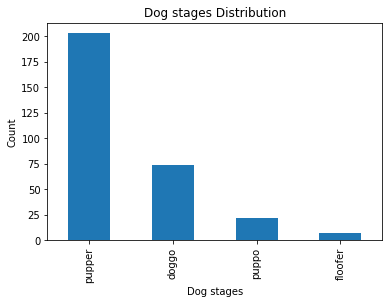

```python
df['dog_stage'].value_counts().plot(kind='bar');
plt.title('Dog stages Distribution')
plt.xlabel('Dog stages')
plt.ylabel('Count')
plt.show()
```

The most dog stage is pupper

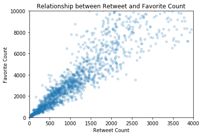

```python
df.plot.scatter(x='retweet_count',y='favorite_count',  xlim=(0,4000), ylim=(0,10000),
               alpha=0.2);
plt.title('Relationship between Retweet and Favorite Count')
plt.xlabel('Retweet Count')
plt.ylabel('Favorite Count')
plt.show()
```

The relation is positive once retweet increase the favorite increase

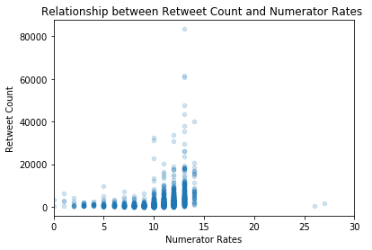

```python
df.plot.scatter(x='rating_numerator',y='retweet_count',
               xlim=(0,30),
               alpha=0.2);
plt.title('Relationship between Retweet Count and Numerator Rates ')
plt.xlabel('Numerator Rates')
plt.ylabel('Retweet Count')
plt.show()
```

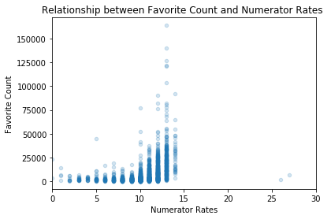

```python
df.plot.scatter(x='rating_numerator',y='favorite_count',
               xlim=(0,30),
               alpha=0.2);
plt.title('Relationship between Favorite Count and Numerator Rates ')
plt.xlabel('Numerator Rates')
plt.ylabel('Favorite Count')
plt.show()
```